# Explorative Data Analysis

Andreas Borup Joergensen, Mette Koch Moeller, Robert Hoestrup

04-06-2021

Downloading the required packages.

```r
library(tidyverse) #Collection of all the good stuff like dplyr, ggplot2 ect.
library(magrittr) #For advanced piping
library(recipes) #For imputing NA's
library(lmtest) #For Granger Cuasality test
library(ggpubr) #For mixing multiple plots together
library(rtweet) #For saving as cvs file
```

# Downloading the data set

The data set is downloaded from [github](https://raw.githubusercontent.com/andreasbj77/Master-thesis/main/Data/DataCreation.csv).

```r
data <- read_csv("https://raw.githubusercontent.com/andreasbj77/Master-thesis/main/Data/DataCreation.csv")
```

# Dealing with NA’s

When predicting the stock price, the different approaches can not handle missing values. First, check if the data set contains any NA’s in the data set and how many.

```r
colSums(is.na(data)) %>% as.data.frame() %>% rename("NAs" = ".") %>% filter(NAs != 0)
```

|  | NAs |
| --- | --- |
| NovoNordisk | 1 |
| OilPrice | 68 |
| USD | 4 |
| GBP | 4 |
| SEK | 4 |
| NOK | 4 |
| CNY | 4 |
| TwoYearBond | 1 |
| TenYearBond | 2 |
| GoldFutures | 20 |

[output cut: 1 more lines]

```r
data %>%
  filter(is.na(NovoNordisk) | is.na(OilPrice) | is.na(USD) | is.na(GBP) | is.na(SEK) | is.na(NOK) | is.na(CNY) | is.na(TwoYearBond) | is.na(TenYearBond) | is.na(GoldFutures)) %>%
  select(Date, NovoNordisk, OilPrice, USD, GBP, SEK, NOK, CNY, TwoYearBond, TenYearBond, GoldFutures)
```

| Date | NovoNordisk | OilPrice | USD | GBP | SEK | NOK | CNY | TwoYearBond | TenYearBond | GoldFutures |
| --- | --- | --- | --- | --- | --- | --- | --- | --- | --- | --- |
| 2010-01-18 | 68.20 | NA | 5.18 | 8.46 | 0.73 | 0.91 | 0.76 | 1.86 | 3.54 | NA |
| 2010-02-15 | 78.28 | NA | 5.47 | 8.58 | 0.75 | 0.92 | 0.80 | 1.78 | 3.55 | NA |
| 2010-05-14 | NA | NA | NA | NA | NA | NA | NA | NA | NA | 1227.40 |
| 2010-05-31 | 93.50 | NA | 6.04 | 8.77 | 0.77 | 0.94 | 0.89 | 0.82 | 2.69 | NA |
| 2010-07-05 | 97.20 | NA | 5.95 | 9.00 | 0.78 | 0.92 | 0.88 | 0.99 | 2.66 | NA |
| 2010-09-06 | 101.30 | NA | 5.78 | 8.88 | 0.80 | 0.94 | 0.85 | 0.84 | 2.42 | NA |
| 2010-11-25 | 115.10 | NA | 5.60 | 8.81 | 0.80 | 0.92 | 0.84 | 1.14 | 2.85 | NA |
| 2011-01-17 | 125.10 | NA | 5.60 | 8.91 | 0.84 | 0.96 | 0.85 | 1.25 | 3.08 | NA |
| 2011-02-21 | 135.40 | NA | 5.45 | 8.85 | 0.85 | 0.96 | 0.83 | 1.46 | 3.25 | NA |
| 2011-05-30 | 129.70 | NA | 5.22 | 8.60 | 0.84 | 0.96 | 0.81 | 1.84 | 3.00 | NA |

[output cut: 58 more lines]

The NA’s seems to have a fairly distribution and is imputed using kNN.

```r
data %<>%
  recipe(Date ~.) %>%
  step_knnimpute(all_predictors()) %>%
  prep() %>%
  juice() %>%
  relocate(Date)
```

# Exploration of the collected data set

Plotting the different values. Since *MaerskA*, *MaerskB* and *USD/DKK* is either rather high or rather low and therefore the y-axis is scaled.

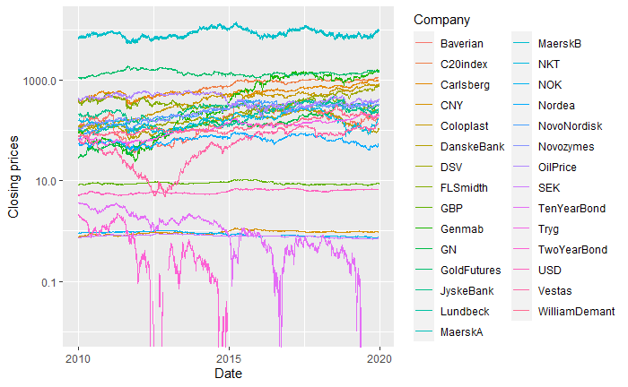

```r
total_data <- gather(data, Company, Value, -Date)
total_data %>%
  ggplot(aes(x = Date, y = Value, color = Company)) +
  geom_line()  + scale_y_log10() +
  labs(x = 'Date', y = "Closing prices")
```

## Correlations

Creating a heatmap of the correlations before 2018-01-01.

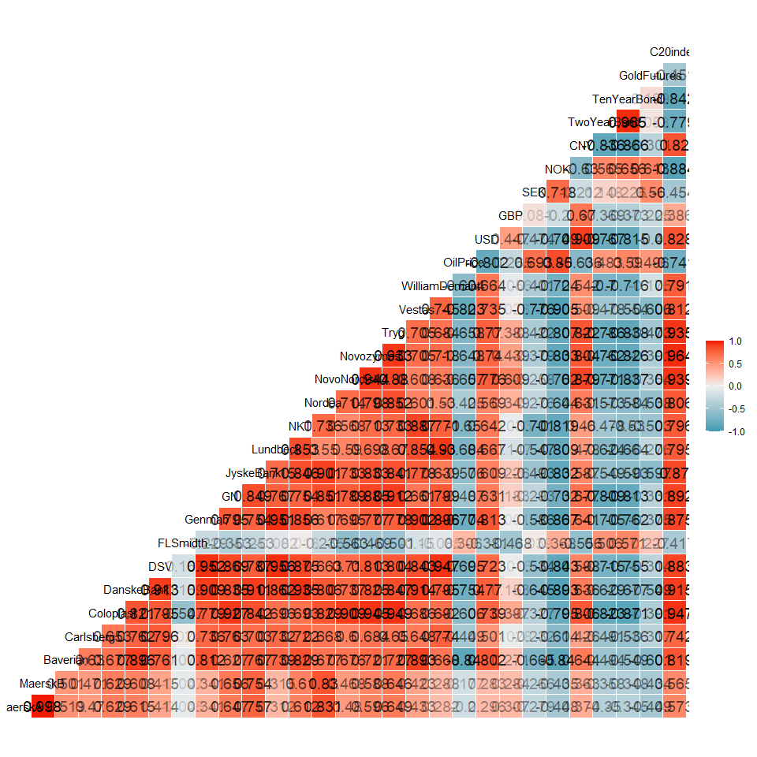

```r
data %>%
  filter(Date < "2018-01-01") %>%
  select(-Date) %>%
  GGally::ggcorr(label = TRUE,
                 label_size = 5,
                 label_round = 3,
                 label_alpha = TRUE)
```

The heatmap shows the most stocks have a positive correlation with each other except *FLSmidth* and *OilPrice*. Several stocks have a very high correlation above 0.90, e.g. *MaerskA* and *MaerskB*, *Lundbeck* and *Genmab*, and *NovoNordisk* and *Novozymes*.

# Choosing the dependent variables

When choosing which variables to forecast, this study has chosen to use the biggest stock from each sector. Plotting the value of the stock 2018-01-02 for each sector.

```r
total_data %>%
  filter(Date == "2018-01-02") %>%
  filter(Company != "OilPrice" & Company != "USD" & Company != "GBP" & Company != "SEK" & Company != "NOK" & Company != "CNY" & Company != "GoldFutures" & Company != "TwoYearBond" & Company != "TenYearBond" & Company != "C20index") %>%
  mutate(Value = Value %>% round(2)) %>%
  arrange(desc(Value)) %>%
  mutate(Sector = ifelse(Company == "Tryg"|Company == "JyskeBank"| Company == "Nordea"| Company == "DanskeBank", "Finance",
                  ifelse(Company == "Baverian"| Company == "Coloplast" | Company == "Demant"|Company == "Genmab"| Company == "GN"| Company == "Lundbeck"|Company == "NovoNordisk"| Company == "Novozymes"| Company == "WilliamDemant", "Health Care",
                  ifelse(Company == "DSV"| Company == "FLSmidth"| Company == "MaerskA" | Company == "MaerskB"|Company == "NKT", "Industry",
                  ifelse(Company == "Carlsberg","Consumption",
                  ifelse(Company == "Vestas", "Energy","test"))))))%>%
  arrange(desc(Sector,Value)) %>% select(-Date)
```

| Company | Value | Sector |
| --- | --- | --- |
| MaerskB | 9554.87 | Industry |
| MaerskA | 9081.85 | Industry |
| DSV | 487.70 | Industry |
| FLSmidth | 368.30 | Industry |
| NKT | 286.20 | Industry |
| Genmab | 1058.00 | Health Care |
| Coloplast | 493.00 | Health Care |
| Novozymes | 351.40 | Health Care |
| NovoNordisk | 333.95 | Health Care |
| Lundbeck | 312.00 | Health Care |

[output cut: 9 more lines]

For Industry, MaerskB is chosen, for Health Care Genmab is chosen, for Finance Jyske Bank is chosen, for Energy Vestas is chosen, and finally, for Consumption Carlsberg is chosen.

Cleaning the environment from unnecessary data sets.

```r
rm(total_data)
```

# Industy - Mærsk B

## Selection of features

This study has chosen two versions of each stock - one only depending on its pasts value and one depending on its pasts value and different features. These features are chosen based on a granger causality test. Calculating granger causality for each value and *MaarskB*. Five lags each chosen for this study.

```r
Order_lags <- 5
DependendVariable <- data$MaerskB

GC1 <- grangertest(DependendVariable ~MaerskA,  order = Order_lags, data = data) %>%
 drop_na() %>% mutate(Company = "MaerskA") %>% rename("GrangerCausitality"="Pr(>F)" ) %>%select(Company,GrangerCausitality) %>% mutate(Correlation = cor(data$MaerskA, DependendVariable))

GC2 <- grangertest(DependendVariable ~ Baverian,  order = Order_lags, data = data) %>%
 drop_na() %>% mutate(Company = "Baverian") %>% rename("GrangerCausitality"="Pr(>F)" ) %>%select(Company,GrangerCausitality)%>% mutate(Correlation = cor(DependendVariable , data$Baverian))

GC3 <- grangertest(DependendVariable ~ Carlsberg,  order = Order_lags, data = data) %>%
 drop_na() %>% mutate(Company = "Carlsberg") %>% rename("GrangerCausitality"="Pr(>F)" ) %>%select(Company,GrangerCausitality) %>% mutate(Correlation = cor(DependendVariable , data$Carlsberg))

GC4 <- grangertest(DependendVariable ~ Coloplast,  order = Order_lags, data = data) %>%
 drop_na() %>% mutate(Company = "Coloplast") %>% rename("GrangerCausitality"="Pr(>F)" ) %>%select(Company,GrangerCausitality) %>% mutate(Correlation = cor(DependendVariable , data$Coloplast))

GC5 <- grangertest(DependendVariable ~ DanskeBank,  order = Order_lags, data = data) %>%
 drop_na() %>% mutate(Company = "DanskeBank") %>% rename("GrangerCausitality"="Pr(>F)" ) %>%select(Company,GrangerCausitality) %>% mutate(Correlation = cor(DependendVariable , data$DanskeBank))

GC6 <- grangertest(DependendVariable ~ DSV,  order = Order_lags, data = data) %>%
 drop_na() %>% mutate(Company = "DSV") %>% rename("GrangerCausitality"="Pr(>F)" ) %>%select(Company,GrangerCausitality) %>% mutate(Correlation = cor(DependendVariable , data$DSV))

GC7 <- grangertest(DependendVariable ~ FLSmidth,  order = Order_lags, data = data) %>%
 drop_na() %>% mutate(Company = "FLSmidth") %>% rename("GrangerCausitality"="Pr(>F)" ) %>%select(Company,GrangerCausitality) %>% mutate(Correlation = cor(DependendVariable , data$FLSmidth))

GC8 <- grangertest(DependendVariable ~ Genmab,  order = Order_lags, data = data) %>%
 drop_na() %>% mutate(Company = "Genmab") %>% rename("GrangerCausitality"="Pr(>F)" ) %>%select(Company,GrangerCausitality) %>% mutate(Correlation = cor(DependendVariable , data$Genmab))

GC9 <- grangertest(DependendVariable ~ GN,  order = Order_lags, data = data) %>%
 drop_na() %>% mutate(Company = "GN") %>% rename("GrangerCausitality"="Pr(>F)" ) %>%select(Company,GrangerCausitality)%>% mutate(Correlation = cor(DependendVariable , data$GN))

GC10 <- grangertest(DependendVariable ~ JyskeBank,  order = Order_lags, data = data) %>%
 drop_na() %>% mutate(Company = "JyskeBank") %>% rename("GrangerCausitality"="Pr(>F)" ) %>%select(Company,GrangerCausitality)%>% mutate(Correlation = cor(DependendVariable , data$JyskeBank))

GC11 <- grangertest(DependendVariable ~ Lundbeck,  order = Order_lags, data = data) %>%
 drop_na() %>% mutate(Company = "Lundbeck") %>% rename("GrangerCausitality"="Pr(>F)" ) %>%select(Company,GrangerCausitality)%>% mutate(Correlation = cor(DependendVariable , data$Lundbeck))

GC12 <- grangertest(DependendVariable ~ NKT,  order = Order_lags, data = data) %>%
 drop_na() %>% mutate(Company = "NKT") %>% rename("GrangerCausitality"="Pr(>F)" ) %>%select(Company,GrangerCausitality)%>% mutate(Correlation = cor(DependendVariable , data$NKT))

GC13 <- grangertest(DependendVariable ~ Nordea,  order = Order_lags, data = data) %>%
 drop_na() %>% mutate(Company = "Nordea") %>% rename("GrangerCausitality"="Pr(>F)" ) %>%select(Company,GrangerCausitality)%>% mutate(Correlation = cor(DependendVariable , data$Nordea))

GC14 <- grangertest(DependendVariable ~ NovoNordisk,  order = Order_lags, data = data) %>%
 drop_na() %>% mutate(Company = "NovoNordisk") %>% rename("GrangerCausitality"="Pr(>F)" ) %>%select(Company,GrangerCausitality) %>% mutate(Correlation = cor(DependendVariable , data$NovoNordisk))

GC15 <- grangertest(DependendVariable ~ Novozymes,  order = Order_lags, data = data) %>%
 drop_na() %>% mutate(Company = "Novozymes") %>% rename("GrangerCausitality"="Pr(>F)" ) %>%select(Company,GrangerCausitality) %>% mutate(Correlation = cor(DependendVariable , data$Novozymes))

GC16 <- grangertest(DependendVariable ~ Tryg,  order = Order_lags, data = data) %>%
 drop_na() %>% mutate(Company = "Tryg") %>% rename("GrangerCausitality"="Pr(>F)" ) %>%select(Company,GrangerCausitality) %>% mutate(Correlation = cor(DependendVariable , data$Tryg))

GC17 <- grangertest(DependendVariable ~ Vestas,  order = Order_lags, data = data) %>%
 drop_na() %>% mutate(Company = "Vestas") %>% rename("GrangerCausitality"="Pr(>F)" ) %>%select(Company,GrangerCausitality) %>% mutate(Correlation = cor(DependendVariable , data$Vestas))

GC18 <- grangertest(DependendVariable ~ WilliamDemant,  order = Order_lags, data = data) %>%
 drop_na() %>% mutate(Company = "WilliamDemant") %>% rename("GrangerCausitality"="Pr(>F)" ) %>%select(Company,GrangerCausitality) %>% mutate(Correlation = cor(DependendVariable , data$WilliamDemant))

GC19 <- grangertest(DependendVariable ~ OilPrice,  order = Order_lags, data = data) %>%
 drop_na() %>% mutate(Company = "OilPrice") %>% rename("GrangerCausitality"="Pr(>F)" ) %>%select(Company,GrangerCausitality) %>% mutate(Correlation = cor(DependendVariable , data$OilPrice))

GC20 <- grangertest(DependendVariable ~ USD,  order = Order_lags, data = data) %>%
 drop_na() %>% mutate(Company = "USD") %>% rename("GrangerCausitality"="Pr(>F)" ) %>%select(Company,GrangerCausitality) %>% mutate(Correlation = cor(DependendVariable , data$USD))

GC21 <- grangertest(DependendVariable ~ GBP,  order = Order_lags, data = data) %>%
 drop_na() %>% mutate(Company = "GBP") %>% rename("GrangerCausitality"="Pr(>F)" ) %>%select(Company,GrangerCausitality) %>% mutate(Correlation = cor(DependendVariable , data$GBP))

GC22 <- grangertest(DependendVariable ~ NOK,  order = Order_lags, data = data) %>%
 drop_na() %>% mutate(Company = "NOK") %>% rename("GrangerCausitality"="Pr(>F)" ) %>%select(Company,GrangerCausitality) %>% mutate(Correlation = cor(DependendVariable , data$NOK))

GC23 <- grangertest(DependendVariable ~ SEK,  order = Order_lags, data = data) %>%
 drop_na() %>% mutate(Company = "SEK") %>% rename("GrangerCausitality"="Pr(>F)" ) %>%select(Company,GrangerCausitality) %>% mutate(Correlation = cor(DependendVariable , data$SEK))

GC24 <- grangertest(DependendVariable ~ CNY,  order = Order_lags, data = data) %>%
 drop_na() %>% mutate(Company = "CNY") %>% rename("GrangerCausitality"="Pr(>F)" ) %>%select(Company,GrangerCausitality) %>% mutate(Correlation = cor(DependendVariable , data$CNY))

GC25 <- grangertest(DependendVariable ~ C20index,  order = Order_lags, data = data) %>%
 drop_na() %>% mutate(Company = "C20index") %>% rename("GrangerCausitality"="Pr(>F)" ) %>%select(Company,GrangerCausitality) %>% mutate(Correlation = cor(DependendVariable , data$C20index))

GC26 <- grangertest(DependendVariable ~ TwoYearBond,  order = Order_lags, data = data) %>%
 drop_na() %>% mutate(Company = "TwoYearBond") %>% rename("GrangerCausitality"="Pr(>F)" ) %>%select(Company,GrangerCausitality) %>% mutate(Correlation = cor(DependendVariable , data$TwoYearBond))

GC27 <- grangertest(DependendVariable ~ TenYearBond,  order = Order_lags, data = data) %>%
 drop_na() %>% mutate(Company = "TenYearBond") %>% rename("GrangerCausitality"="Pr(>F)" ) %>%select(Company,GrangerCausitality) %>% mutate(Correlation = cor(DependendVariable , data$TenYearBond))

GC28 <- grangertest(DependendVariable ~ GoldFutures,  order = Order_lags, data = data) %>%
 drop_na() %>% mutate(Company = "GoldFutures") %>% rename("GrangerCausitality"="Pr(>F)" ) %>%select(Company,GrangerCausitality) %>% mutate(Correlation = cor(DependendVariable , data$GoldFutures))

GC_MaerskB <- rbind(GC1,GC2,GC3,GC4,GC5,GC6,GC7,GC8,GC9,GC10,GC11,GC12,GC13,GC14,GC15,GC16,GC17,GC18,GC19,GC20,GC21,GC22,GC23,GC24,GC25,GC26,GC27,GC28) %>% as.data.frame()
```

```r
GC_MaerskB %>%
    filter(GrangerCausitality <= 0.05)
```

| Company | GrangerCausitality | Correlation |
| --- | --- | --- |
| FLSmidth | 0.0089351157 | -0.03533715 |
| NovoNordisk | 0.0126128444 | 0.32672665 |
| OilPrice | 0.0005013453 | -0.12765793 |
| USD | 0.0269556905 | 0.16830343 |

```r
data_MaerskB <- data %>%
  select(Date, MaerskB, FLSmidth, NovoNordisk, OilPrice, USD)
```

Cleaning the environment from unnecessary data sets.

```r
rm(GC1,GC2,GC3,GC4,GC5,GC6,GC7,GC8,GC9,GC10,GC11,GC12,GC13,GC14,GC15,GC16,GC17,GC18,GC19,GC20,GC21,GC22,GC23,GC24,GC25,GC26,GC27,GC28,GC_MaerskB,DependendVariable,Order_lags)
```

## Investergation the new data set

Plotting each variable individually.

```r
Plot1 <-  data_MaerskB  %>% ggplot(aes(y = MaerskB, x = Date,  col= "red") ) + geom_line()  + theme(legend.position = "none")  + labs(y="", x = "Maersk B")

Plot2 <-  data_MaerskB  %>% ggplot(aes(y = FLSmidth, x = Date)) + geom_line( col = "deepskyblue3") + theme(legend.position = "none") + labs(y="", x = " FLSmidth")

Plot3 <-  data_MaerskB %>%   ggplot(aes(y = NovoNordisk, x = Date)) + geom_line(col= "darkolivegreen4") + theme(legend.position = "none") + labs(y="", x = " Novo Nordisk")

Plot4 <-  data_MaerskB %>% ggplot(aes(y = OilPrice, x = Date)) + geom_line(col = "darkgreen") + theme(legend.position = "none")     + labs(y="", x = "Oil Price")

Plot5 <-  data_MaerskB %>% ggplot(aes(y = USD, x = Date)) + geom_line(col = "darkgreen") + theme(legend.position = "none")     + labs(y="", x = "USD")
```

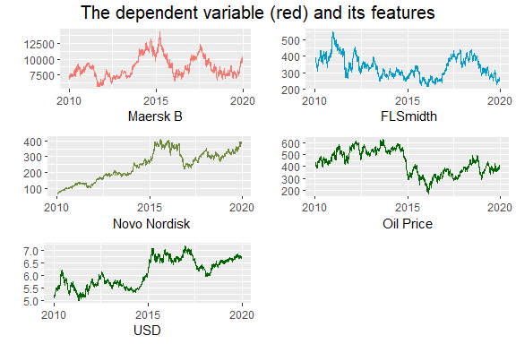

```r
Plot_Collected<-ggarrange(Plot1, Plot2, Plot3, Plot4, Plot5, ncol = 2, nrow = 3)
annotate_figure(Plot_Collected, top = text_grob("The dependent variable (red) and its features", size = 15))
```

### Boxplot

Creating a summary in order to investigate each variable.

```r
data_MaerskB %>%  select(-Date) %>%
  summary()
```

```
    MaerskB         FLSmidth      NovoNordisk        OilPrice          USD
 Min.   : 5646   Min.   :214.3   Min.   : 66.78   Min.   :172.3   Min.   :5.010
 1st Qu.: 7509   1st Qu.:282.1   1st Qu.:170.80   1st Qu.:348.6   1st Qu.:5.590
 Median : 8307   Median :324.4   Median :254.00   Median :433.9   Median :6.050
 Mean   : 8760   Mean   :333.9   Mean   :244.20   Mean   :431.2   Mean   :6.106
 3rd Qu.: 9971   3rd Qu.:384.2   3rd Qu.:319.70   3rd Qu.:525.7   3rd Qu.:6.640
 Max.   :14306   Max.   :548.0   Max.   :410.70   Max.   :629.0   Max.   :7.170
```

Creating a box plot for each variable. (I created two boxplot because I am not sure which one to pick).

```r
Plot1 <-  data_MaerskB %>% ggplot(aes(y = MaerskB, x = Date,  col= "red") ) +   geom_boxplot()  + theme(legend.position = "none") + labs(y="", x = "Maersk B")

Plot2 <-  data_MaerskB%>% ggplot(aes(y = FLSmidth, x = Date)) + geom_boxplot(col= "deepskyblue3") + theme(legend.position = "none") + labs(y="", x = " FLSmidth")

Plot3 <-  data_MaerskB %>%ggplot(aes(y = NovoNordisk, x = Date)) + geom_boxplot( col = "darkolivegreen4") + theme(legend.position = "none") + labs(y="", x = " Novo Nordisk")

Plot4 <-  data_MaerskB %>% ggplot(aes(y = OilPrice, x = Date)) + geom_boxplot(col = "darkgreen") + theme(legend.position = "none") + labs(y="", x = "Oil Price")

Plot5 <-  data_MaerskB %>% ggplot(aes(y = USD, x = Date)) + geom_boxplot(col = "darkgreen") + theme(legend.position = "none") + labs(y="", x = "USD")
```

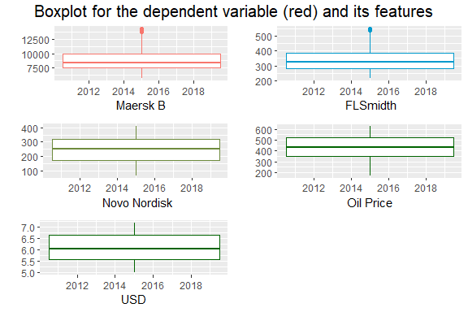

```r
Plot_Collected<-ggarrange(Plot1, Plot2, Plot3, Plot4, Plot5, ncol = 2, nrow = 3)
annotate_figure(Plot_Collected, top = text_grob("Boxplot for the dependent variable (red) and its features", size = 15))
```

When plotting the date by using the *gather* function, the stocks is plotted in alphabetic order. To get the same order as the other plots, the plots is recorded into a number and a factor, then the number is given a level, and then given a number is given a label corresponding the name of the company.

```r
data_MaerskB_plot<- gather(data_MaerskB, Company, Value, -Date)
data_MaerskB_plot %<>% mutate(Company = ifelse(Company == "MaerskB", 1,
                           ifelse(Company == "FLSmidth", 2,
                           ifelse(Company == "NovoNordisk", 3,
                           ifelse(Company == "OilPrice", 4,
                           ifelse(Company == "USD", 5, "test"))))))
data_MaerskB_plot$Company <- factor(as.numeric(data_MaerskB_plot$Company),
          levels = c(1, 2, 3, 4, 5),
          labels = c("MaerskB","FLSmidth", "NovoNordisk","OilPrice", "USD"))
```

The second box plot.

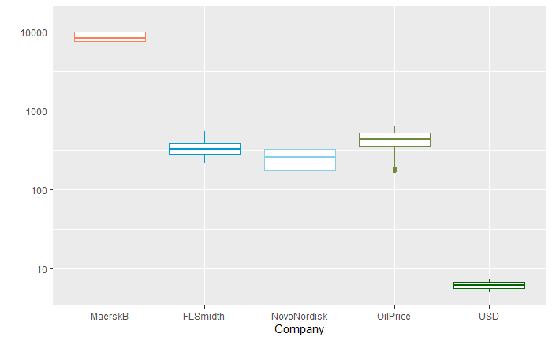

```r
data_MaerskB_plot%>%
ggplot( aes(x=Company, y=Value)) + geom_boxplot(col = c("coral", "deepskyblue3", "skyblue", "darkolivegreen4","darkgreen"))+ scale_y_log10()  + labs(y="", x = "Company")
```

A yearly boxplot is made for each variable. This shows if the rise/fall the stock did a year were distributed on a few observation or were more consistent.

```r
Plot1 <- data_MaerskB %>% select(Date, MaerskB) %>%mutate(Year = format(Date, "%Y" )) %>%  ggplot(aes(x=Year, y=MaerskB)) + geom_boxplot(col = "coral")+ theme(legend.position = "none") + labs(y="", x = "Maersk B")

Plot2 <-  data_MaerskB%>% select(Date,FLSmidth) %>%mutate(Year = format(Date, "%Y" ))%>% ggplot(aes(x = Year, y = FLSmidth)) + geom_boxplot( col = "deepskyblue3") + theme(legend.position = "none") + labs(y="", x = " FLSmidth")

Plot3 <-  data_MaerskB %>%select(Date, NovoNordisk) %>%mutate(Year = format(Date, "%Y" )) %>% ggplot(aes(x = Year, y = NovoNordisk)) + geom_boxplot(col= "darkolivegreen4") + theme(legend.position = "none") + labs(y="", x = " Novo Nordisk")

Plot4 <-  data_MaerskB %>%select(Date, OilPrice) %>%mutate(Year = format(Date, "%Y" )) %>% ggplot(aes(x = Year, y = OilPrice)) + geom_boxplot(col = "darkgreen") + theme(legend.position = "none") + labs(y="", x = "Oil Price")

Plot5 <-  data_MaerskB %>%select(Date, USD) %>%mutate(Year = format(Date, "%Y" )) %>% ggplot(aes(x = Year, y = USD)) + geom_boxplot(col = "darkgreen") + theme(legend.position = "none") + labs(y="", x = "USD")
```

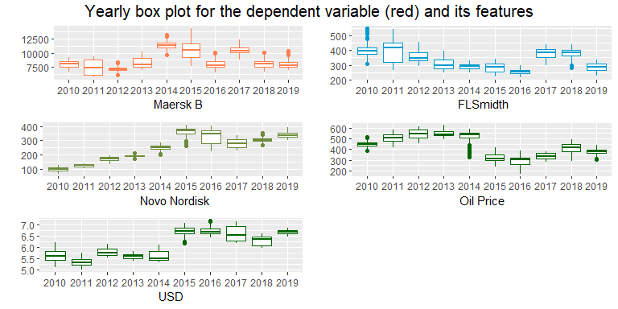

```r
Plot_Collected<-ggarrange(Plot1, Plot2, Plot3, Plot4, Plot5, ncol = 2, nrow = 3)
annotate_figure(Plot_Collected, top = text_grob("Yearly box plot for the dependent variable (red) and its features", size = 15))
```

### Density plot

Plotting a density plot and the mean for each variable.

```r
Plot1 <-  data_MaerskB %>% ggplot(aes(x = MaerskB, col= "red") ) +   geom_density()  + theme(legend.position = "none")+ geom_vline(aes(xintercept=mean(MaerskB)),
            color="darkgrey", linetype="dashed", size=1) + labs(y="", x = "Maersk B")

Plot2 <-  data_MaerskB%>% ggplot(aes(x = FLSmidth)) + geom_density( col = "deepskyblue3") + theme(legend.position = "none") + geom_vline(aes(xintercept=mean(FLSmidth)),
            color="darkgrey", linetype="dashed", size=1) + labs(y="", x = " FLSmidth")

Plot3 <-  data_MaerskB %>%ggplot(aes(x = NovoNordisk)) + geom_density(col= "darkolivegreen4") + theme(legend.position = "none")+ geom_vline(aes(xintercept=mean(NovoNordisk)),
            color="darkgrey", linetype="dashed", size=1) + labs(y="", x = " Novo Nordisk")

Plot4 <-  data_MaerskB %>% ggplot(aes(x = OilPrice)) + geom_density(col = "darkgreen") + theme(legend.position = "none")+ geom_vline(aes(xintercept=mean(OilPrice)),
            color="darkgrey", linetype="dashed", size=1) + labs(y="", x = "Oil Price")

Plot5 <-  data_MaerskB %>% ggplot(aes(x = USD)) + geom_density(col = "darkgreen") + theme(legend.position = "none")+ geom_vline(aes(xintercept=mean(USD)),
            color="darkgrey", linetype="dashed", size=1) + labs(y="", x = "USD")
```

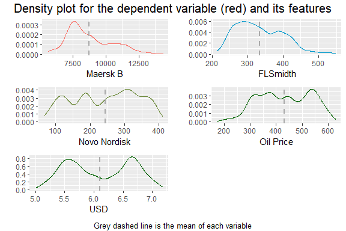

```r
Plot_Collected<-ggarrange(Plot1, Plot2, Plot3, Plot4, Plot5, ncol = 2, nrow = 3)
annotate_figure(Plot_Collected, top = text_grob("Density plot for the dependent variable (red) and its features", size = 15),  bottom = text_grob("Grey dashed line is the mean of each variable", size = 10))
```

## The change in stock

Creating a new data set for change in price in per cent.

```r
data_MaerskB_Change <- data_MaerskB %>%
  mutate(MaerskB  = ((MaerskB-lag(MaerskB))/lag(MaerskB))*100,
         FLSmidth = ((FLSmidth-lag(FLSmidth))/lag(FLSmidth))*100,
         NovoNordisk = ((NovoNordisk-lag(NovoNordisk))/lag(NovoNordisk))*100,
         OilPrice = ((OilPrice-lag(OilPrice))/lag(OilPrice))*100,
         USD = ((USD-lag(USD))/lag(USD))*100) %>%
         drop_na()
```

Plotting the change in per cent for each variable individually. This shows how volatile each variable is.

```r
Plot1 <-  data_MaerskB_Change  %>%ggplot(aes(y = MaerskB, x = Date,  col= "red") ) + geom_line()  + theme(legend.position = "none") + labs(y = "", x = "Maersk B")

Plot2 <-  data_MaerskB_Change  %>%  ggplot(aes(y = FLSmidth, x = Date)) + geom_line( col = "deepskyblue3") + theme(legend.position = "none") + labs(y = "", x = " FLSmidth")

Plot3 <-  data_MaerskB_Change  %>% ggplot(aes(y = NovoNordisk, x = Date)) + geom_line(col= "darkolivegreen4") + theme(legend.position = "none") + labs(y = "" ,x = " Novo Nordisk")

Plot4 <-  data_MaerskB_Change  %>% ggplot(aes(y = OilPrice, x = Date)) + geom_line(col = "darkgreen") + theme(legend.position = "none") + labs(y="", x = "Oil Price")

Plot5 <-  data_MaerskB_Change  %>% ggplot(aes(y = USD, x = Date)) + geom_line(col = "darkgreen") + theme(legend.position = "none") + labs(y="", x = "USD")
```

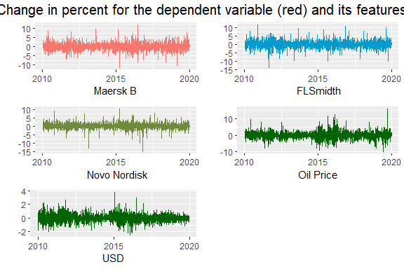

```r
Plot_Collected<-ggarrange(Plot1, Plot2, Plot3, Plot4, Plot5, ncol = 2, nrow = 3)
annotate_figure(Plot_Collected, top = text_grob("Change in percent for the dependent variable (red) and its features", size = 15))
```

Plotting the distribition for each variable

```r
Plot1 <- data_MaerskB_Change %>%ggplot(aes(x = MaerskB, col= "red") )  +   geom_density()  + theme(legend.position = "none")+ geom_vline(aes(xintercept=mean(MaerskB)),color="darkgrey", linetype="dashed", size=1)+ scale_x_continuous(limits = c(-5,5))+ scale_y_continuous(limits = c(0,0.35))  + labs(y = "", x = "Maersk B")

Plot2 <-  data_MaerskB_Change  %>% ggplot(aes(x = FLSmidth)) + geom_density(col = "deepskyblue3") + theme(legend.position = "none") + geom_vline(aes(xintercept=mean(FLSmidth)), color="darkgrey", linetype="dashed", size=1)+ scale_x_continuous(limits = c(-5,5))+ scale_y_continuous(limits = c(0,0.35)) + labs(y = "", x = " FLSmidth")

Plot3 <-  data_MaerskB_Change %>%ggplot(aes(x = NovoNordisk)) + geom_density(col= "darkolivegreen4") + theme(legend.position = "none")+ geom_vline(aes(xintercept=mean(NovoNordisk)),
            color="darkgrey", linetype="dashed", size=1) + scale_x_continuous(limits = c(-5,5))+ scale_y_continuous(limits = c(0,0.35))  + labs(y = "" ,x = " Novo Nordisk")

Plot4 <-  data_MaerskB_Change  %>% ggplot(aes(x = OilPrice)) + geom_density(col = "darkgreen") + theme(legend.position = "none")+ geom_vline(aes(xintercept=mean(OilPrice)),
            color="darkgrey", linetype="dashed", size=1) + scale_x_continuous(limits = c(-5,5)) + scale_y_continuous(limits = c(0,0.35)) + labs(y="", x = "Oil Price")

Plot5 <-  data_MaerskB_Change  %>% ggplot(aes(x = USD)) + geom_density(col = "darkgreen") + theme(legend.position = "none")+ geom_vline(aes(xintercept=mean(USD)),
            color="darkgrey", linetype="dashed", size=1) + scale_x_continuous(limits = c(-5,5)) + scale_y_continuous(limits = c(0,0.35)) + labs(y="", x = "USD")
```

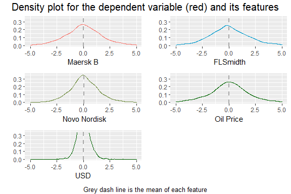

```r
Plot_Collected<-ggarrange(Plot1, Plot2, Plot3, Plot4, Plot5, ncol = 2, nrow = 3)
annotate_figure(Plot_Collected, top = text_grob("Density plot for the dependent variable (red) and its features", size = 15),  bottom = text_grob("Grey dash line is the mean of each feature", size = 10))
```

Cleaning the environment from unnecessary data sets.

```r
rm(Plot1, Plot_Baverian, Plot2, Plot3, Plot4, Plot5, Plot_Collected, data_MaerskB_plot, data_MaerskB_Change)
```

## Saving the data set

The Mærsk B data set is now done and ready for forecast. It is saved as a cvs-file and uploaded on [Github](https://github.com/andreasbj77/Master-thesis?fbclid=IwAR1-uXAsXOvRxWwDzpfhzjiqyOhil9E4wklrK03_fRMZhLQ7EYTrooHzTw0)

```r
write_as_csv(data_MaerskB,"DataCreationMaerskB.csv")
```

```r
rm(data_MaerskB)
```

# Health Care - Genmab

## Selection of features

Calculating granger causality for each value and *Genmab*. Five lags each chosen for this study.

```r
Order_lags <- 5
DependendVariable <- data$Genmab

GC1 <- grangertest(DependendVariable ~MaerskA,  order = Order_lags, data = data) %>%
 drop_na() %>% mutate(Company = "MaerskA") %>% rename("GrangerCausitality"="Pr(>F)" ) %>%select(Company,GrangerCausitality) %>% mutate(Correlation = cor(data$MaerskA, DependendVariable))

GC2 <- grangertest(DependendVariable ~MaerskB,  order = Order_lags, data = data) %>%
 drop_na() %>% mutate(Company = "MaerskB") %>% rename("GrangerCausitality"="Pr(>F)" ) %>%select(Company,GrangerCausitality) %>% mutate(Correlation = cor(data$MaerskB, DependendVariable))

GC3 <- grangertest(DependendVariable ~ Baverian,  order = Order_lags, data = data) %>%
 drop_na() %>% mutate(Company = "Baverian") %>% rename("GrangerCausitality"="Pr(>F)" ) %>%select(Company,GrangerCausitality)%>% mutate(Correlation = cor(DependendVariable , data$Baverian))

GC4 <- grangertest(DependendVariable ~ Carlsberg,  order = Order_lags, data = data) %>%
 drop_na() %>% mutate(Company = "Carlsberg") %>% rename("GrangerCausitality"="Pr(>F)" ) %>%select(Company,GrangerCausitality) %>% mutate(Correlation = cor(DependendVariable , data$Carlsberg))

GC5 <- grangertest(DependendVariable ~ Coloplast,  order = Order_lags, data = data) %>%
 drop_na() %>% mutate(Company = "Coloplast") %>% rename("GrangerCausitality"="Pr(>F)" ) %>%select(Company,GrangerCausitality) %>% mutate(Correlation = cor(DependendVariable , data$Coloplast))

GC6 <- grangertest(DependendVariable ~ DanskeBank,  order = Order_lags, data = data) %>%
 drop_na() %>% mutate(Company = "DanskeBank") %>% rename("GrangerCausitality"="Pr(>F)" ) %>%select(Company,GrangerCausitality) %>% mutate(Correlation = cor(DependendVariable , data$DanskeBank))

GC7 <- grangertest(DependendVariable ~ DSV,  order = Order_lags, data = data) %>%
 drop_na() %>% mutate(Company = "DSV") %>% rename("GrangerCausitality"="Pr(>F)" ) %>%select(Company,GrangerCausitality) %>% mutate(Correlation = cor(DependendVariable , data$DSV))

GC8 <- grangertest(DependendVariable ~ FLSmidth,  order = Order_lags, data = data) %>%
 drop_na() %>% mutate(Company = "FLSmidth") %>% rename("GrangerCausitality"="Pr(>F)" ) %>%select(Company,GrangerCausitality) %>% mutate(Correlation = cor(DependendVariable , data$FLSmidth))

GC9 <- grangertest(DependendVariable ~ GN,  order = Order_lags, data = data) %>%
 drop_na() %>% mutate(Company = "GN") %>% rename("GrangerCausitality"="Pr(>F)" ) %>%select(Company,GrangerCausitality)%>% mutate(Correlation = cor(DependendVariable , data$GN))

GC10 <- grangertest(DependendVariable ~ JyskeBank,  order = Order_lags, data = data) %>%
 drop_na() %>% mutate(Company = "JyskeBank") %>% rename("GrangerCausitality"="Pr(>F)" ) %>%select(Company,GrangerCausitality)%>% mutate(Correlation = cor(DependendVariable , data$JyskeBank))

GC11 <- grangertest(DependendVariable ~ Lundbeck,  order = Order_lags, data = data) %>%
 drop_na() %>% mutate(Company = "Lundbeck") %>% rename("GrangerCausitality"="Pr(>F)" ) %>%select(Company,GrangerCausitality)%>% mutate(Correlation = cor(DependendVariable , data$Lundbeck))

GC12 <- grangertest(DependendVariable ~ NKT,  order = Order_lags, data = data) %>%
 drop_na() %>% mutate(Company = "NKT") %>% rename("GrangerCausitality"="Pr(>F)" ) %>%select(Company,GrangerCausitality)%>% mutate(Correlation = cor(DependendVariable , data$NKT))

GC13 <- grangertest(DependendVariable ~ Nordea,  order = Order_lags, data = data) %>%
 drop_na() %>% mutate(Company = "Nordea") %>% rename("GrangerCausitality"="Pr(>F)" ) %>%select(Company,GrangerCausitality)%>% mutate(Correlation = cor(DependendVariable , data$Nordea))

GC14 <- grangertest(DependendVariable ~ NovoNordisk,  order = Order_lags, data = data) %>%
 drop_na() %>% mutate(Company = "NovoNordisk") %>% rename("GrangerCausitality"="Pr(>F)" ) %>%select(Company,GrangerCausitality) %>% mutate(Correlation = cor(DependendVariable , data$NovoNordisk))

GC15 <- grangertest(DependendVariable ~ Novozymes,  order = Order_lags, data = data) %>%
 drop_na() %>% mutate(Company = "Novozymes") %>% rename("GrangerCausitality"="Pr(>F)" ) %>%select(Company,GrangerCausitality) %>% mutate(Correlation = cor(DependendVariable , data$Novozymes))

GC16 <- grangertest(DependendVariable ~ Tryg,  order = Order_lags, data = data) %>%
 drop_na() %>% mutate(Company = "Tryg") %>% rename("GrangerCausitality"="Pr(>F)" ) %>%select(Company,GrangerCausitality) %>% mutate(Correlation = cor(DependendVariable , data$Tryg))

GC17 <- grangertest(DependendVariable ~ Vestas,  order = Order_lags, data = data) %>%
 drop_na() %>% mutate(Company = "Vestas") %>% rename("GrangerCausitality"="Pr(>F)" ) %>%select(Company,GrangerCausitality) %>% mutate(Correlation = cor(DependendVariable , data$Vestas))

GC18 <- grangertest(DependendVariable ~ WilliamDemant,  order = Order_lags, data = data) %>%
 drop_na() %>% mutate(Company = "WilliamDemant") %>% rename("GrangerCausitality"="Pr(>F)" ) %>%select(Company,GrangerCausitality) %>% mutate(Correlation = cor(DependendVariable , data$WilliamDemant))

GC19 <- grangertest(DependendVariable ~ OilPrice,  order = Order_lags, data = data) %>%
 drop_na() %>% mutate(Company = "OilPrice") %>% rename("GrangerCausitality"="Pr(>F)" ) %>%select(Company,GrangerCausitality) %>% mutate(Correlation = cor(DependendVariable , data$OilPrice))

GC20 <- grangertest(DependendVariable ~ USD,  order = Order_lags, data = data) %>%
 drop_na() %>% mutate(Company = "USD") %>% rename("GrangerCausitality"="Pr(>F)" ) %>%select(Company,GrangerCausitality) %>% mutate(Correlation = cor(DependendVariable , data$USD))

GC21 <- grangertest(DependendVariable ~ GBP,  order = Order_lags, data = data) %>%
 drop_na() %>% mutate(Company = "GBP") %>% rename("GrangerCausitality"="Pr(>F)" ) %>%select(Company,GrangerCausitality) %>% mutate(Correlation = cor(DependendVariable , data$GBP))

GC22 <- grangertest(DependendVariable ~ NOK,  order = Order_lags, data = data) %>%
 drop_na() %>% mutate(Company = "NOK") %>% rename("GrangerCausitality"="Pr(>F)" ) %>%select(Company,GrangerCausitality) %>% mutate(Correlation = cor(DependendVariable , data$NOK))

GC23 <- grangertest(DependendVariable ~ SEK,  order = Order_lags, data = data) %>%
 drop_na() %>% mutate(Company = "SEK") %>% rename("GrangerCausitality"="Pr(>F)" ) %>%select(Company,GrangerCausitality) %>% mutate(Correlation = cor(DependendVariable , data$SEK))

GC24 <- grangertest(DependendVariable ~ CNY,  order = Order_lags, data = data) %>%
 drop_na() %>% mutate(Company = "CNY") %>% rename("GrangerCausitality"="Pr(>F)" ) %>%select(Company,GrangerCausitality) %>% mutate(Correlation = cor(DependendVariable , data$CNY))

GC25 <- grangertest(DependendVariable ~ C20index,  order = Order_lags, data = data) %>%
 drop_na() %>% mutate(Company = "C20index") %>% rename("GrangerCausitality"="Pr(>F)" ) %>%select(Company,GrangerCausitality) %>% mutate(Correlation = cor(DependendVariable , data$C20index))

GC26 <- grangertest(DependendVariable ~ TwoYearBond,  order = Order_lags, data = data) %>%
 drop_na() %>% mutate(Company = "TwoYearBond") %>% rename("GrangerCausitality"="Pr(>F)" ) %>%select(Company,GrangerCausitality) %>% mutate(Correlation = cor(DependendVariable , data$TwoYearBond))

GC27 <- grangertest(DependendVariable ~ TenYearBond,  order = Order_lags, data = data) %>%
 drop_na() %>% mutate(Company = "TenYearBond") %>% rename("GrangerCausitality"="Pr(>F)" ) %>%select(Company,GrangerCausitality) %>% mutate(Correlation = cor(DependendVariable , data$TenYearBond))

GC28 <- grangertest(DependendVariable ~ GoldFutures,  order = Order_lags, data = data) %>%
 drop_na() %>% mutate(Company = "GoldFutures") %>% rename("GrangerCausitality"="Pr(>F)" ) %>%select(Company,GrangerCausitality) %>% mutate(Correlation = cor(DependendVariable , data$GoldFutures))

GC_Genmab <- rbind(GC1,GC2,GC3,GC4,GC5,GC6,GC7,GC8,GC9,GC10,GC11,GC12,GC13,GC14,GC15,GC16,GC17,GC18,GC19,GC20,GC21,GC22,GC23,GC24,GC25,GC26,GC27,GC28) %>% as.data.frame()
```

The significant features is chosen.

```r
GC_Genmab %>%
    filter(GrangerCausitality <= 0.05)
```

| Company | GrangerCausitality | Correlation |
| --- | --- | --- |
| FLSmidth | 0.022547590 | -0.2052713 |
| Lundbeck | 0.007710195 | 0.8884408 |
| WilliamDemant | 0.017491655 | 0.7909237 |
| OilPrice | 0.024685493 | -0.7196666 |
| USD | 0.005534550 | 0.8137066 |
| NOK | 0.031832711 | -0.9058993 |

```r
data_Genmab <- data %>%
  select(Date, Genmab, FLSmidth, Lundbeck, WilliamDemant, OilPrice, USD, NOK)
```

Cleaning the environment from unnecessary data sets.

```r
rm(GC1,GC2,GC3,GC4,GC5,GC6,GC7,GC8,GC9,GC10,GC11,GC12,GC13,GC14,GC15,GC16,GC17,GC18,GC19,GC20,GC21,GC22,GC23,GC24,GC25,GC26,GC27,GC28,GC_Genmab,DependendVariable,Order_lags)
```

## Investegating

Plotting each variable individually.

```r
Plot1 <-  data_Genmab  %>% ggplot(aes(y = Genmab, x = Date,  col= "red") ) + geom_line()  + theme(legend.position = "none")  + labs(y="" ,x = "Genmab")

Plot2 <-  data_Genmab  %>% ggplot(aes(y = FLSmidth, x = Date)) + geom_line(col = "cornflowerblue") + theme(legend.position = "none") + labs(y= "", x = " FLSmidth")

Plot3 <-  data_Genmab %>% ggplot(aes(y = Lundbeck, x = Date)) + geom_line(col= "skyblue") + theme(legend.position = "none") + labs(y="", x = "Lundbeck")

Plot4 <-  data_Genmab %>%   ggplot(aes(y = WilliamDemant, x = Date)) + geom_line(col= "darkolivegreen4") + theme(legend.position = "none") + labs(y="", x = " WilliamDemant")

Plot5 <-  data_Genmab %>% ggplot(aes(y = OilPrice, x = Date)) + geom_line(col = "deepskyblue4") + theme(legend.position = "none")     + labs(y="", x = "Oil Price")

Plot6 <-  data_Genmab %>% ggplot(aes(y =USD, x = Date)) + geom_line(col = "deepskyblue3") + theme(legend.position = "none")     + labs(y="" ,x = "USD")

Plot7 <-  data_Genmab %>%   ggplot(aes(y = NOK, x = Date)) + geom_line(col= "darkgreen") + theme(legend.position = "none") + labs(y="", x = "NOK")
```

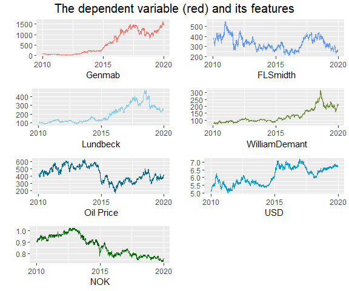

```r
Plot_Collected<-ggarrange(Plot1, Plot2, Plot3, Plot4, Plot5, Plot6, Plot7, ncol = 2, nrow = 4)
annotate_figure(Plot_Collected, top = text_grob("The dependent variable (red) and its features", size = 15))
```

### Boxplot

Creating a summary in order to investigate each variable.

```r
data_Genmab %>% select(-Date) %>%  summary()
```

```
     Genmab           FLSmidth        Lundbeck      WilliamDemant       OilPrice
 Min.   :  23.88   Min.   :214.3   Min.   : 81.65   Min.   : 71.68   Min.   :172.3
 1st Qu.:  71.86   1st Qu.:282.1   1st Qu.:113.00   1st Qu.: 93.08   1st Qu.:348.6
 Median : 360.35   Median :324.4   Median :138.55   Median :106.00   Median :433.9
 Mean   : 591.21   Mean   :333.9   Mean   :195.23   Mean   :129.64   Mean   :431.2
 3rd Qu.:1128.00   3rd Qu.:384.2   3rd Qu.:269.65   3rd Qu.:166.28   3rd Qu.:525.7
 Max.   :1620.00   Max.   :548.0   Max.   :475.90   Max.   :316.20   Max.   :629.0
      USD             NOK
 Min.   :5.010   Min.   :0.7300
 1st Qu.:5.590   1st Qu.:0.7900
 Median :6.050   Median :0.8800
 Mean   :6.106   Mean   :0.8703
 3rd Qu.:6.640   3rd Qu.:0.9500
 Max.   :7.170   Max.   :1.0200
```

Besides *Genmab*, *Genmab* has both the lowest and highest value.

Creating a box plot for each variable. (I created two boxplot because I am not sure which one to pick).

```r
Plot1 <-  data_Genmab %>% ggplot(aes(y = Genmab, x = Date,  col= "red") ) +   geom_boxplot()  + theme(legend.position = "none") + labs(y="" ,x = "Genmab")

Plot2 <-  data_Genmab%>% ggplot(aes(y = FLSmidth, x = Date)) + geom_boxplot(col = "cornflowerblue") + theme(legend.position = "none") + labs(y="", x = " FLSmidth")

Plot3 <-  data_Genmab  %>% ggplot(aes(y = Lundbeck, x = Date)) + geom_boxplot(col= "skyblue") + theme(legend.position = "none")  + labs(y="", x = "Lundbeck")

Plot4 <-  data_Genmab %>% ggplot(aes(y = WilliamDemant, x = Date)) + geom_boxplot(col= "darkolivegreen4") + theme(legend.position = "none") + labs(y="", x = "William Demant")

Plot5 <-  data_Genmab %>% ggplot(aes(y = OilPrice, x = Date)) + geom_boxplot(col = "deepskyblue4") + theme(legend.position = "none")     + labs(y="", x = "Oil Price")

Plot6 <- data_Genmab %>% ggplot(aes(y =USD, x = Date)) + geom_boxplot(col = "deepskyblue3") + theme(legend.position = "none")     + labs(y="" ,x = "USD")

Plot7 <-  data_Genmab %>%ggplot(aes(y = NOK, x = Date)) + geom_boxplot(col= "darkgreen") + theme(legend.position = "none") + labs(y="", x = "NOK")
```

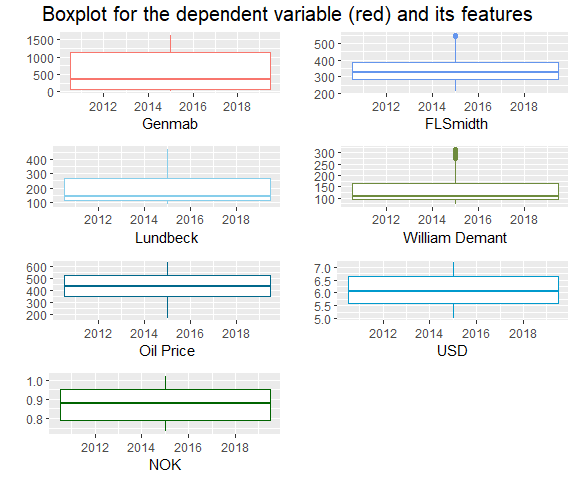

```r
Plot_Collected<-ggarrange(Plot1, Plot2, Plot3, Plot4, Plot5, Plot6, Plot7, ncol = 2, nrow = 4)
annotate_figure(Plot_Collected, top = text_grob("Boxplot for the dependent variable (red) and its features", size = 15))
```

When plotting the date by using the *gather* function, the stocks is plotted in alphabetic order. To get the same order as the other plots, the plots is recorded into a number and a factor, then the number is given a level, and then given a number is given a label corresponding the name of the company.

```r
data_Genmab_plot<- gather(data_Genmab, Company, Value, -Date)
data_Genmab_plot %<>% mutate(Company = ifelse(Company == "Genmab", 1,
                           ifelse(Company == "FLSmidth", 2,
                           ifelse(Company == "Lundbeck", 3,
                           ifelse(Company == "WilliamDemant", 4,
                           ifelse(Company == "OilPrice", 5,
                           ifelse(Company == "USD", 6,
                           ifelse(Company == "NOK", 7, "test"))))))))
data_Genmab_plot$Company <- factor(as.numeric(data_Genmab_plot$Company),
          levels = c(1, 2, 3, 4, 5, 6, 7),
          labels = c("Genmab", "FLSmidth", "Lundbeck", "William Demant", "OilPrice", "USD", "NOK"))
```

The second box plot.

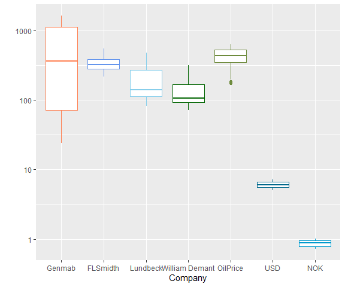

```r
data_Genmab_plot%>%
ggplot( aes(x=Company, y=Value)) + geom_boxplot(col = c("coral", "cornflowerblue", "skyblue","darkgreen", "darkolivegreen4", "deepskyblue4", "deepskyblue3"))+ scale_y_log10()  + labs(y="", x = "Company")
```

A yearly boxplot is made for each variable. This shows if the rise/fall the stock did a year were distributed on a few observation or were more consistent.

```r
Plot1 <- data_Genmab %>% select(Date, Genmab) %>%mutate(Year = format(Date, "%Y" )) %>%  ggplot(aes(x=Year, y=Genmab)) + geom_boxplot(col = "coral")+ theme(legend.position = "none") + labs(y="" ,x = "Genmab")

Plot2 <-  data_Genmab%>% select(Date,FLSmidth) %>%mutate(Year = format(Date, "%Y" ))%>% ggplot(aes(x = Year, y = FLSmidth)) + geom_boxplot(col = "cornflowerblue") + theme(legend.position = "none") + labs(y="", x = " FLSmidth")

Plot3 <-  data_Genmab  %>% select(Date, Lundbeck) %>%mutate(Year = format(Date, "%Y" )) %>% ggplot(aes(x = Year, y = Lundbeck)) + geom_boxplot(col= "skyblue") + theme(legend.position = "none")  + labs(y="", x = "Lundbeck")

Plot4 <-  data_Genmab %>%select(Date, WilliamDemant) %>% mutate(Year = format(Date, "%Y" )) %>% ggplot(aes(x = Year, y = WilliamDemant)) + geom_boxplot(col= "darkolivegreen4") + theme(legend.position = "none") + labs(y="", x = "WilliamDemant")

Plot5 <-  data_Genmab%>%select(Date, OilPrice) %>% mutate(Year = format(Date, "%Y" )) %>% ggplot(aes(x = Year, y = OilPrice)) + geom_boxplot(col = "deepskyblue4") + theme(legend.position = "none")     + labs(y="", x = "Oil Price")

Plot6 <-  data_Genmab%>%select(Date, USD) %>% mutate(Year = format(Date, "%Y" )) %>% ggplot(aes(x = Year, y =USD)) + geom_boxplot(col = "deepskyblue3") + theme(legend.position = "none")     + labs(y="" ,x = "USD")

Plot7 <-  data_Genmab %>%select(Date, NOK) %>%mutate(Year = format(Date, "%Y" )) %>% ggplot(aes(x = Year, y = NOK)) + geom_boxplot(col= "darkgreen") + theme(legend.position = "none") + labs(y="", x = "NOK")
```

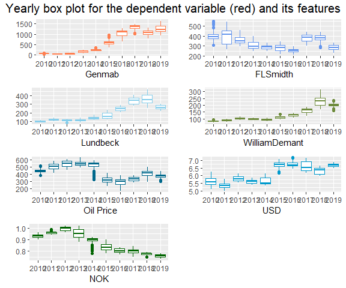

```r
Plot_Collected<-ggarrange(Plot1, Plot2, Plot3, Plot4, Plot5, Plot6, Plot7, ncol = 2, nrow = 4)
annotate_figure(Plot_Collected, top = text_grob("Yearly box plot for the dependent variable (red) and its features", size = 15))
```

### Density plot

Plotting a density plot and the mean for each variable.

```r
Plot1 <-  data_Genmab %>% ggplot(aes(x = Genmab, col= "red") ) +   geom_density()  + theme(legend.position = "none")+ geom_vline(aes(xintercept=mean(Genmab)),
            color="darkgrey", linetype="dashed", size=1) + labs(y="" ,x = "Genmab")

Plot2 <-  data_Genmab%>% ggplot(aes(x = FLSmidth)) + geom_density( col = "cornflowerblue") + theme(legend.position = "none") + geom_vline(aes(xintercept=mean(FLSmidth)),
            color="darkgrey", linetype="dashed", size=1) + labs(y="", x = " FLSmidth")

Plot3 <-  data_Genmab  %>% ggplot(aes(x = Lundbeck)) + geom_density(col= "skyblue") + theme(legend.position = "none")+ geom_vline(aes(xintercept=mean(Lundbeck)),
            color="darkgrey", linetype="dashed", size=1)   + labs(y="", x = "Lundbeck")

Plot4 <-  data_Genmab %>% ggplot(aes(x = WilliamDemant)) + geom_density(col= "darkolivegreen4") + theme(legend.position = "none")+ geom_vline(aes(xintercept=mean(WilliamDemant)),
            color="darkgrey", linetype="dashed", size=1) + labs(y="", x = "William Demant")

Plot5 <-  data_Genmab %>% ggplot(aes(x = OilPrice)) + geom_density(col = "deepskyblue4") + theme(legend.position = "none") +geom_vline(aes(xintercept=mean(OilPrice)),
            color="darkgrey", linetype="dashed", size=1) + labs(y="", x = "Oil Price")

Plot6 <-  data_Genmab %>% ggplot(aes(x =USD)) + geom_density(col = "deepskyblue3") + geom_vline(aes(xintercept=mean(USD)),
            color="darkgrey", linetype="dashed", size=1) + theme(legend.position = "none")     + labs(y="" ,x = "USD")

Plot7 <-  data_Genmab %>%ggplot(aes(x = NOK)) + geom_density(col= "darkgreen") + theme(legend.position = "none")+ geom_vline(aes(xintercept=mean(NOK)),
            color="darkgrey", linetype="dashed", size=1) + labs(y="", x = "NOK")
```

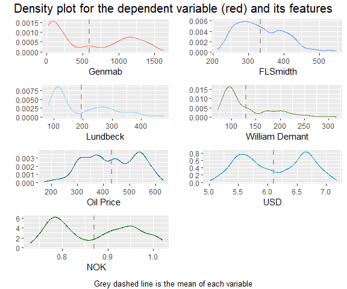

```r
Plot_Collected<-ggarrange(Plot1, Plot2, Plot3, Plot4, Plot5, Plot6, Plot7, ncol = 2, nrow = 4)
annotate_figure(Plot_Collected, top = text_grob("Density plot for the dependent variable (red) and its features", size = 15),  bottom = text_grob("Grey dashed line is the mean of each variable", size = 10))
```

## The change in stock

Creating a new data set for change in price in per cent.

```r
data_Genmab_Change <- data_Genmab %>%
  mutate(Genmab  = ((Genmab-lag(Genmab))/lag(Genmab))*100,
         FLSmidth = ((FLSmidth-lag(FLSmidth))/lag(FLSmidth))*100,
         Lundbeck = ((Lundbeck-lag(Lundbeck))/lag(Lundbeck))*100,
         WilliamDemant = ((WilliamDemant-lag(WilliamDemant))/lag(WilliamDemant))*100,
         OilPrice = ((OilPrice-lag(OilPrice))/lag(OilPrice))*100,
         USD = ((USD-lag(USD))/lag(USD))*100,
         NOK = ((NOK-lag(NOK))/lag(NOK))*100,) %>%
         drop_na()
```

Plotting the change in per cent for each variable individually. This shows how volatile each variable is.

```r
Plot1 <-  data_Genmab_Change  %>% ggplot(aes(y = Genmab, x = Date,  col= "red") ) + geom_line()  + theme(legend.position = "none")  + labs(y="" ,x = "Genmab")

Plot2 <-  data_Genmab_Change  %>% ggplot(aes(y = FLSmidth, x = Date)) + geom_line(col = "cornflowerblue") + theme(legend.position = "none") + labs(y= "", x = " FLSmidth")

Plot3 <-  data_Genmab_Change %>% ggplot(aes(y = Lundbeck, x = Date)) + geom_line(col= "skyblue") + theme(legend.position = "none") + labs(y="", x = "Lundbeck")

Plot4 <-  data_Genmab_Change %>%   ggplot(aes(y = WilliamDemant, x = Date)) + geom_line(col= "darkolivegreen4") + theme(legend.position = "none") + labs(y="", x = " WilliamDemant")

Plot5 <-  data_Genmab_Change %>% ggplot(aes(y = OilPrice, x = Date)) + geom_line(col = "deepskyblue4") + theme(legend.position = "none")     + labs(y="", x = "Oil Price")

Plot6 <-  data_Genmab_Change %>% ggplot(aes(y =USD, x = Date)) + geom_line(col = "deepskyblue3") + theme(legend.position = "none")     + labs(y="" ,x = "USD")

Plot7 <-  data_Genmab_Change %>%   ggplot(aes(y = NOK, x = Date)) + geom_line(col= "darkgreen") + theme(legend.position = "none") + labs(y="", x = "NOK")
```

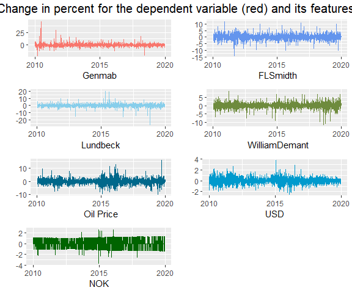

```r
Plot_Collected<-ggarrange(Plot1, Plot2, Plot3, Plot4, Plot5, Plot6, Plot7, ncol = 2, nrow = 4)
annotate_figure(Plot_Collected, top = text_grob("Change in percent for the dependent variable (red) and its features", size = 15))
```

```r
Plot1 <-  data_Genmab_Change %>% ggplot(aes(x = Genmab, col= "red") ) +   geom_density()  + theme(legend.position = "none")+ geom_vline(aes(xintercept=mean(Genmab)),
            color="darkgrey", linetype="dashed", size=1) + labs(y="" ,x = "Genmab") + scale_x_continuous(limits = c(-5,5))+ scale_y_continuous(limits = c(0,0.85))

Plot2 <-  data_Genmab_Change%>% ggplot(aes(x = FLSmidth)) + geom_density( col = "cornflowerblue") + theme(legend.position = "none") + geom_vline(aes(xintercept=mean(FLSmidth)),
            color="darkgrey", linetype="dashed", size=1) + labs(y="", x = " FLSmidth")+ scale_x_continuous(limits = c(-5,5))+ scale_y_continuous(limits = c(0,0.85))

Plot3 <-  data_Genmab_Change  %>% ggplot(aes(x = Lundbeck)) + geom_density(col= "skyblue") + theme(legend.position = "none")+ geom_vline(aes(xintercept=mean(Lundbeck)),
            color="darkgrey", linetype="dashed", size=1)   + labs(y="", x = "Lundbeck")+ scale_x_continuous(limits = c(-5,5))+ scale_y_continuous(limits = c(0,0.85))

Plot4 <-  data_Genmab_Change %>% ggplot(aes(x = WilliamDemant)) + geom_density(col= "darkolivegreen4") + theme(legend.position = "none")+ geom_vline(aes(xintercept=mean(WilliamDemant)),
            color="darkgrey", linetype="dashed", size=1) + labs(y="", x = "William Demant")+ scale_x_continuous(limits = c(-5,5))+ scale_y_continuous(limits = c(0,0.85))

Plot5 <-  data_Genmab_Change %>% ggplot(aes(x = OilPrice)) + geom_density(col = "deepskyblue4") + theme(legend.position = "none") +geom_vline(aes(xintercept=mean(OilPrice)),
            color="darkgrey", linetype="dashed", size=1) + labs(y="", x = "Oil Price")+ scale_x_continuous(limits = c(-5,5))+ scale_y_continuous(limits = c(0,0.85))

Plot6 <-  data_Genmab_Change %>% ggplot(aes(x =USD)) + geom_density(col = "deepskyblue3") + geom_vline(aes(xintercept=mean(USD)),
            color="darkgrey", linetype="dashed", size=1) + theme(legend.position = "none")     + labs(y="" ,x = "USD")+ scale_x_continuous(limits = c(-5,5))+ scale_y_continuous(limits = c(0,0.85))

Plot7 <-  data_Genmab_Change %>%ggplot(aes(x = NOK)) + geom_density(col= "darkgreen") + theme(legend.position = "none")+ geom_vline(aes(xintercept=mean(NOK)),
            color="darkgrey", linetype="dashed", size=1) + labs(y="", x = "NOK")+ scale_x_continuous(limits = c(-5,5))+ scale_y_continuous(limits = c(0,0.85))
```

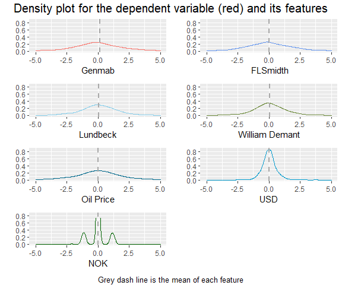

```r
Plot_Collected<-ggarrange(Plot1, Plot2, Plot3, Plot4, Plot5, Plot6, Plot7, ncol = 2, nrow = 4)
annotate_figure(Plot_Collected, top = text_grob("Density plot for the dependent variable (red) and its features", size = 15),  bottom = text_grob("Grey dash line is the mean of each feature", size = 10))
```

Cleaning the environment from unnecessary data sets.

```r
rm(Plot1, Plot_Baverian, Plot2, Plot3, Plot4, Plot5, Plot6, Plot7, Plot_Collected, data_Genmab_plot, data_Genmab_Change)
```

## Saving the data set

The Genmab data set is now done and ready for forecast. It is saved as a cvs-file and uploaded on [Github](https://github.com/andreasbj77/Master-thesis?fbclid=IwAR1-uXAsXOvRxWwDzpfhzjiqyOhil9E4wklrK03_fRMZhLQ7EYTrooHzTw0)

```r
write_as_csv(data_Genmab,"DataCreationGenmab.csv")
```

```r
rm(data_Genmab)
```

# Finance - Jyske Bank

## Selection of features

Calculating granger causality for each value and *JyskeBank*. Five lags each chosen for this study.

```r
Order_lags <- 5
DependendVariable <- data$JyskeBank

GC1 <- grangertest(DependendVariable ~MaerskA,  order = Order_lags, data = data) %>%
 drop_na() %>% mutate(Company = "MaerskA") %>% rename("GrangerCausitality"="Pr(>F)" ) %>%select(Company,GrangerCausitality) %>% mutate(Correlation = cor(data$MaerskA, DependendVariable))

GC2 <- grangertest(DependendVariable ~MaerskB,  order = Order_lags, data = data) %>%
 drop_na() %>% mutate(Company = "MaerskB") %>% rename("GrangerCausitality"="Pr(>F)" ) %>%select(Company,GrangerCausitality) %>% mutate(Correlation = cor(data$MaerskB, DependendVariable))

GC3 <- grangertest(DependendVariable ~ Baverian,  order = Order_lags, data = data) %>%
 drop_na() %>% mutate(Company = "Baverian") %>% rename("GrangerCausitality"="Pr(>F)" ) %>%select(Company,GrangerCausitality)%>% mutate(Correlation = cor(DependendVariable , data$Baverian))

GC4 <- grangertest(DependendVariable ~ Carlsberg,  order = Order_lags, data = data) %>%
 drop_na() %>% mutate(Company = "Carlsberg") %>% rename("GrangerCausitality"="Pr(>F)" ) %>%select(Company,GrangerCausitality) %>% mutate(Correlation = cor(DependendVariable , data$Carlsberg))

GC5 <- grangertest(DependendVariable ~ Coloplast,  order = Order_lags, data = data) %>%
 drop_na() %>% mutate(Company = "Coloplast") %>% rename("GrangerCausitality"="Pr(>F)" ) %>%select(Company,GrangerCausitality) %>% mutate(Correlation = cor(DependendVariable , data$Coloplast))

GC6 <- grangertest(DependendVariable ~ DanskeBank,  order = Order_lags, data = data) %>%
 drop_na() %>% mutate(Company = "DanskeBank") %>% rename("GrangerCausitality"="Pr(>F)" ) %>%select(Company,GrangerCausitality) %>% mutate(Correlation = cor(DependendVariable , data$DanskeBank))

GC7 <- grangertest(DependendVariable ~ DSV,  order = Order_lags, data = data) %>%
 drop_na() %>% mutate(Company = "DSV") %>% rename("GrangerCausitality"="Pr(>F)" ) %>%select(Company,GrangerCausitality) %>% mutate(Correlation = cor(DependendVariable , data$DSV))

GC8 <- grangertest(DependendVariable ~ FLSmidth,  order = Order_lags, data = data) %>%
 drop_na() %>% mutate(Company = "FLSmidth") %>% rename("GrangerCausitality"="Pr(>F)" ) %>%select(Company,GrangerCausitality) %>% mutate(Correlation = cor(DependendVariable , data$FLSmidth))

GC9 <- grangertest(DependendVariable ~ Genmab,  order = Order_lags, data = data) %>%
 drop_na() %>% mutate(Company = "Genmab") %>% rename("GrangerCausitality"="Pr(>F)" ) %>%select(Company,GrangerCausitality) %>% mutate(Correlation = cor(DependendVariable , data$Genmab))

GC10 <- grangertest(DependendVariable ~ GN,  order = Order_lags, data = data) %>%
 drop_na() %>% mutate(Company = "GN") %>% rename("GrangerCausitality"="Pr(>F)" ) %>%select(Company,GrangerCausitality)%>% mutate(Correlation = cor(DependendVariable , data$GN))

GC11 <- grangertest(DependendVariable ~ Lundbeck,  order = Order_lags, data = data) %>%
 drop_na() %>% mutate(Company = "Lundbeck") %>% rename("GrangerCausitality"="Pr(>F)" ) %>%select(Company,GrangerCausitality)%>% mutate(Correlation = cor(DependendVariable , data$Lundbeck))

GC12 <- grangertest(DependendVariable ~ NKT,  order = Order_lags, data = data) %>%
 drop_na() %>% mutate(Company = "NKT") %>% rename("GrangerCausitality"="Pr(>F)" ) %>%select(Company,GrangerCausitality)%>% mutate(Correlation = cor(DependendVariable , data$NKT))

GC13 <- grangertest(DependendVariable ~ Nordea,  order = Order_lags, data = data) %>%
 drop_na() %>% mutate(Company = "Nordea") %>% rename("GrangerCausitality"="Pr(>F)" ) %>%select(Company,GrangerCausitality)%>% mutate(Correlation = cor(DependendVariable , data$Nordea))

GC14 <- grangertest(DependendVariable ~ NovoNordisk,  order = Order_lags, data = data) %>%
 drop_na() %>% mutate(Company = "NovoNordisk") %>% rename("GrangerCausitality"="Pr(>F)" ) %>%select(Company,GrangerCausitality) %>% mutate(Correlation = cor(DependendVariable , data$NovoNordisk))

GC15 <- grangertest(DependendVariable ~ Novozymes,  order = Order_lags, data = data) %>%
 drop_na() %>% mutate(Company = "Novozymes") %>% rename("GrangerCausitality"="Pr(>F)" ) %>%select(Company,GrangerCausitality) %>% mutate(Correlation = cor(DependendVariable , data$Novozymes))

GC16 <- grangertest(DependendVariable ~ Tryg,  order = Order_lags, data = data) %>%
 drop_na() %>% mutate(Company = "Tryg") %>% rename("GrangerCausitality"="Pr(>F)" ) %>%select(Company,GrangerCausitality) %>% mutate(Correlation = cor(DependendVariable , data$Tryg))

GC17 <- grangertest(DependendVariable ~ Vestas,  order = Order_lags, data = data) %>%
 drop_na() %>% mutate(Company = "Vestas") %>% rename("GrangerCausitality"="Pr(>F)" ) %>%select(Company,GrangerCausitality) %>% mutate(Correlation = cor(DependendVariable , data$Vestas))

GC18 <- grangertest(DependendVariable ~ WilliamDemant,  order = Order_lags, data = data) %>%
 drop_na() %>% mutate(Company = "WilliamDemant") %>% rename("GrangerCausitality"="Pr(>F)" ) %>%select(Company,GrangerCausitality) %>% mutate(Correlation = cor(DependendVariable , data$WilliamDemant))

GC19 <- grangertest(DependendVariable ~ OilPrice,  order = Order_lags, data = data) %>%
 drop_na() %>% mutate(Company = "OilPrice") %>% rename("GrangerCausitality"="Pr(>F)" ) %>%select(Company,GrangerCausitality) %>% mutate(Correlation = cor(DependendVariable , data$OilPrice))

GC20 <- grangertest(DependendVariable ~ USD,  order = Order_lags, data = data) %>%
 drop_na() %>% mutate(Company = "USD") %>% rename("GrangerCausitality"="Pr(>F)" ) %>%select(Company,GrangerCausitality) %>% mutate(Correlation = cor(DependendVariable , data$USD))

GC21 <- grangertest(DependendVariable ~ GBP,  order = Order_lags, data = data) %>%
 drop_na() %>% mutate(Company = "GBP") %>% rename("GrangerCausitality"="Pr(>F)" ) %>%select(Company,GrangerCausitality) %>% mutate(Correlation = cor(DependendVariable , data$GBP))

GC22 <- grangertest(DependendVariable ~ NOK,  order = Order_lags, data = data) %>%
 drop_na() %>% mutate(Company = "NOK") %>% rename("GrangerCausitality"="Pr(>F)" ) %>%select(Company,GrangerCausitality) %>% mutate(Correlation = cor(DependendVariable , data$NOK))

GC23 <- grangertest(DependendVariable ~ SEK,  order = Order_lags, data = data) %>%
 drop_na() %>% mutate(Company = "SEK") %>% rename("GrangerCausitality"="Pr(>F)" ) %>%select(Company,GrangerCausitality) %>% mutate(Correlation = cor(DependendVariable , data$SEK))

GC24 <- grangertest(DependendVariable ~ CNY,  order = Order_lags, data = data) %>%
 drop_na() %>% mutate(Company = "CNY") %>% rename("GrangerCausitality"="Pr(>F)" ) %>%select(Company,GrangerCausitality) %>% mutate(Correlation = cor(DependendVariable , data$CNY))

GC25 <- grangertest(DependendVariable ~ C20index,  order = Order_lags, data = data) %>%
 drop_na() %>% mutate(Company = "C20index") %>% rename("GrangerCausitality"="Pr(>F)" ) %>%select(Company,GrangerCausitality) %>% mutate(Correlation = cor(DependendVariable , data$C20index))

GC26 <- grangertest(DependendVariable ~ TwoYearBond,  order = Order_lags, data = data) %>%
 drop_na() %>% mutate(Company = "TwoYearBond") %>% rename("GrangerCausitality"="Pr(>F)" ) %>%select(Company,GrangerCausitality) %>% mutate(Correlation = cor(DependendVariable , data$TwoYearBond))

GC27 <- grangertest(DependendVariable ~ TenYearBond,  order = Order_lags, data = data) %>%
 drop_na() %>% mutate(Company = "TenYearBond") %>% rename("GrangerCausitality"="Pr(>F)" ) %>%select(Company,GrangerCausitality) %>% mutate(Correlation = cor(DependendVariable , data$TenYearBond))

GC28 <- grangertest(DependendVariable ~ GoldFutures,  order = Order_lags, data = data) %>%
 drop_na() %>% mutate(Company = "GoldFutures") %>% rename("GrangerCausitality"="Pr(>F)" ) %>%select(Company,GrangerCausitality) %>% mutate(Correlation = cor(DependendVariable , data$GoldFutures))

GC_JyskeBank <- rbind(GC1,GC2,GC3,GC4,GC5,GC6,GC7,GC8,GC9,GC10,GC11,GC12,GC13,GC14,GC15,GC16,GC17,GC18,GC19,GC20,GC21,GC22,GC23,GC24,GC25,GC26,GC27,GC28) %>% as.data.frame()
```

The significant features is chosen.

```r
GC_JyskeBank %>%
    filter(GrangerCausitality <= 0.05)
```

| Company | GrangerCausitality | Correlation |
| --- | --- | --- |
| Lundbeck | 0.040356368 | 0.6505756 |
| NKT | 0.007276728 | 0.8071532 |
| Nordea | 0.004909621 | 0.8273746 |
| TenYearBond | 0.018389956 | -0.4635354 |

```r
data_JyskeBank <- data %>%
  select(Date, JyskeBank, Lundbeck, NKT, Nordea, TenYearBond)
```

Cleaning the environment from unnecessary data sets.

```r
rm(GC1,GC2,GC3,GC4,GC5,GC6,GC7,GC8,GC9,GC10,GC11,GC12,GC13,GC14,GC15,GC16,GC17,GC18,GC19,GC20,GC21,GC22,GC23,GC24,GC25,GC26,GC27,GC28,GC_JyskeBank,DependendVariable,Order_lags)
```

The significant features is chosen.

## Investegating

Plotting each variable individually.

```r
Plot1 <-  data_JyskeBank  %>% ggplot(aes(y = JyskeBank, x = Date,  col= "red")) + geom_line()  + theme(legend.position = "none")  + labs(y="" ,x = "Jyske Bank")

Plot2 <-  data_JyskeBank  %>% ggplot(aes(y = Lundbeck, x = Date)) + geom_line(col = "cornflowerblue") + theme(legend.position = "none") + labs(y= "", x = "Lundbeck")

Plot3 <-  data_JyskeBank %>% ggplot(aes(y = NKT, x = Date)) + geom_line(col= "skyblue") + theme(legend.position = "none") + labs(y="", x = "NKT")

Plot4 <-  data_JyskeBank %>%   ggplot(aes(y = Nordea, x = Date)) + geom_line(col= "darkgreen") + theme(legend.position = "none") + labs(y="", x = "Nordea")

Plot5 <-  data_JyskeBank %>%   ggplot(aes(y = TenYearBond, x = Date)) + geom_line(col= "darkolivegreen4") + theme(legend.position = "none") + labs(y="", x = "TenYearBond")
```

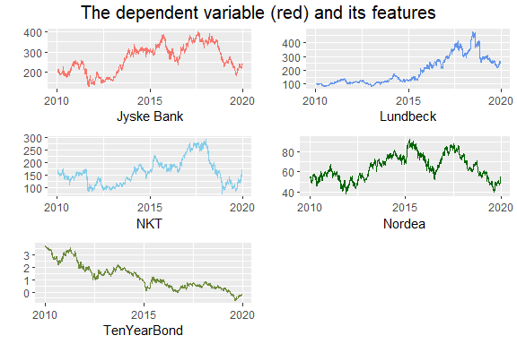

```r
Plot_Collected<-ggarrange(Plot1, Plot2, Plot3, Plot4, Plot5, ncol = 2, nrow = 3)
annotate_figure(Plot_Collected, top = text_grob("The dependent variable (red) and its features", size = 15))
```

### Boxplot

Creating a summary in order to investigate each variable.

```r
data_JyskeBank %>% select(-Date) %>%  summary()
```

```
   JyskeBank        Lundbeck           NKT            Nordea       TenYearBond
 Min.   :131.3   Min.   : 81.65   Min.   : 74.7   Min.   :38.36   Min.   :-0.690
 1st Qu.:206.9   1st Qu.:113.00   1st Qu.:118.6   1st Qu.:54.95   1st Qu.: 0.420
 Median :269.4   Median :138.55   Median :156.3   Median :64.08   Median : 1.010
 Mean   :267.3   Mean   :195.23   Mean   :160.4   Mean   :64.67   Mean   : 1.228
 3rd Qu.:321.5   3rd Qu.:269.65   3rd Qu.:185.9   3rd Qu.:74.74   3rd Qu.: 1.840
 Max.   :398.0   Max.   :475.90   Max.   :292.0   Max.   :92.85   Max.   : 3.690
```

Creating a box plot for each variable. (I created two boxplot because I am not sure which one to pick).

```r
Plot1 <-  data_JyskeBank %>%ggplot(aes(y = JyskeBank, x = Date,  col= "red")) +   geom_boxplot()  + theme(legend.position = "none") + labs(y="" ,x = "Jyske Bank")

Plot2 <-  data_JyskeBank%>% ggplot(aes(y = Lundbeck, x = Date)) + geom_boxplot(col = "cornflowerblue") + theme(legend.position = "none") + labs(y= "", x = "Lundbeck")

Plot3 <-  data_JyskeBank  %>% ggplot(aes(y = NKT, x = Date)) + geom_boxplot(col= "skyblue") + theme(legend.position = "none") + labs(y="", x = "NKT")

Plot4 <-  data_JyskeBank %>%ggplot(aes(y = Nordea, x = Date)) + geom_boxplot(col= "darkgreen") + theme(legend.position = "none") + labs(y="", x = "Nordea")

Plot5 <-  data_JyskeBank %>% ggplot(aes(y = TenYearBond, x = Date)) + geom_boxplot(col= "darkolivegreen4") + theme(legend.position = "none") + labs(y="", x = "TenYearBond")
```

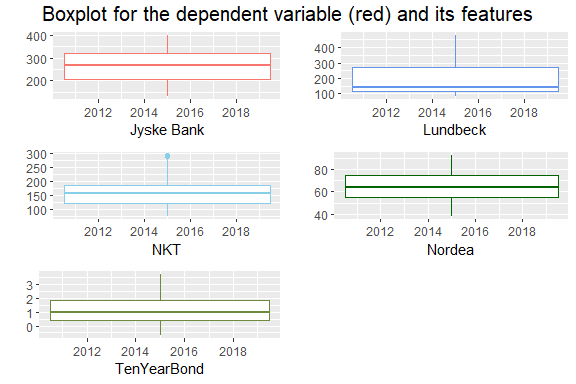

```r
Plot_Collected<-ggarrange(Plot1, Plot2, Plot3, Plot4, Plot5, ncol = 2, nrow = 3)
annotate_figure(Plot_Collected, top = text_grob("Boxplot for the dependent variable (red) and its features", size = 15))
```

When plotting the date by using the *gather* function, the stocks is plotted in alphabetic order. To get the same order as the other plots, the plots is recorded into a number and a factor, then the number is given a level, and then given a number is given a label corresponding the name of the company.

```r
data_JyskeBank_plot<- gather(data_JyskeBank, Company, Value, -Date)
data_JyskeBank_plot %<>% mutate(Company = ifelse(Company == "JyskeBank", 1,
                           ifelse(Company == "Lundbeck", 2,
                           ifelse(Company == "NKT", 3,
                           ifelse(Company == "Nordea", 4,
                           ifelse(Company == "TenYearBond", 5, "test"))))))
data_JyskeBank_plot$Company <- factor(as.numeric(data_JyskeBank_plot$Company),
          levels = c(1, 2, 3, 4, 5),
          labels = c("JyskeBank", "Lundbeck","NKT", "Nordea", "TenYearBond"))
```

The second box plot.

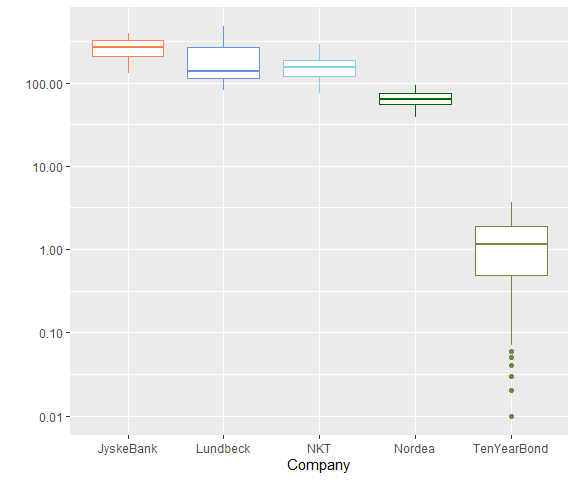

```r
data_JyskeBank_plot %>% ggplot( aes(x=Company, y=Value)) + geom_boxplot(col = c("coral", "cornflowerblue", "skyblue","darkgreen", "darkolivegreen4"))+ scale_y_log10()  + labs(y="", x = "Company")
```

A yearly boxplot is made for each variable. This shows if the rise/fall the stock did a year were distributed on a few observation or were more consistent.

```r
Plot1 <- data_JyskeBank %>% select(Date, JyskeBank) %>%mutate(Year = format(Date, "%Y" )) %>%  ggplot(aes(x=Year, y=JyskeBank)) + geom_boxplot(col = "coral")+ theme(legend.position = "none") + labs(y="" ,x = "Jyske Bank")

Plot2 <-  data_JyskeBank%>% select(Date,Lundbeck) %>% mutate(Year = format(Date, "%Y" ))%>% ggplot(aes(x = Year, y = Lundbeck)) + geom_boxplot(col = "cornflowerblue") + theme(legend.position = "none") + labs(y= "", x = "Lundbeck")

Plot3 <-  data_JyskeBank  %>% select(Date, NKT) %>%mutate(Year = format(Date, "%Y" )) %>% ggplot(aes(x = Year, y = NKT)) + geom_boxplot(col= "skyblue") + theme(legend.position = "none") + labs(y="", x = "NKT")

Plot4 <-  data_JyskeBank %>% select(Date, Nordea) %>% mutate(Year = format(Date, "%Y" )) %>% ggplot(aes(x = Year, y = Nordea)) + geom_boxplot(col= "darkgreen") + theme(legend.position = "none") + labs(y="", x = "Nordea")

Plot5 <-  data_JyskeBank %>%select(Date, TenYearBond) %>% mutate(Year = format(Date, "%Y" )) %>% ggplot(aes(x = Year, y = TenYearBond)) + geom_boxplot(col= "darkolivegreen4") + theme(legend.position = "none") + labs(y="", x = "TenYearBond")
```

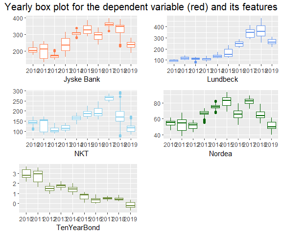

```r
Plot_Collected<-ggarrange(Plot1, Plot2, Plot3, Plot4, Plot5, ncol = 2, nrow = 3)
annotate_figure(Plot_Collected, top = text_grob("Yearly box plot for the dependent variable (red) and its features", size = 15))
```

### Density plot

Plotting a density plot and the mean for each variable.

```r
Plot1 <-  data_JyskeBank %>% ggplot(aes(x = JyskeBank, col= "red") ) +   geom_density()  + theme(legend.position = "none")+ geom_vline(aes(xintercept=mean(JyskeBank)),
            color="darkgrey", linetype="dashed", size=1) + labs(y="" ,x = "Jyske Bank")

Plot2 <-  data_JyskeBank%>% ggplot(aes(x = Lundbeck)) + geom_density( col = "cornflowerblue") + theme(legend.position = "none") + geom_vline(aes(xintercept=mean(Lundbeck)),
            color="darkgrey", linetype="dashed", size=1) + labs(y= "", x = "Lundbeck")

Plot3 <-  data_JyskeBank  %>% ggplot(aes(x = NKT)) + geom_density(col= "skyblue") + theme(legend.position = "none")+ geom_vline(aes(xintercept=mean(NKT)),
            color="darkgrey", linetype="dashed", size=1) + labs(y="", x = "NKT")

Plot4 <-  data_JyskeBank %>%ggplot(aes(x = Nordea)) + geom_density(col= "darkgreen") + theme(legend.position = "none")+ geom_vline(aes(xintercept=mean(Nordea)),
            color="darkgrey", linetype="dashed", size=1) + labs(y="", x = "Nordea")

Plot5 <-  data_JyskeBank %>% ggplot(aes(x = TenYearBond)) + geom_density(col= "darkolivegreen4") + theme(legend.position = "none")+ geom_vline(aes(xintercept=mean(TenYearBond)),
            color="darkgrey", linetype="dashed", size=1) + labs(y="", x = "TenYearBond")
```

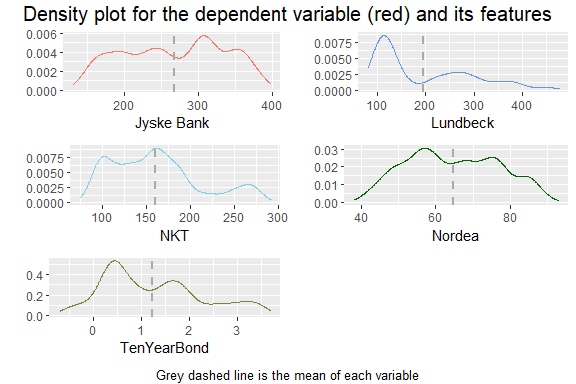

```r
Plot_Collected<-ggarrange(Plot1, Plot2, Plot3, Plot4, Plot5, ncol = 2, nrow = 3)
annotate_figure(Plot_Collected, top = text_grob("Density plot for the dependent variable (red) and its features", size = 15),  bottom = text_grob("Grey dashed line is the mean of each variable", size = 10))
```

## The change in stock

Creating a new data set for change in price in per cent.

```r
data_JyskeBank_Change <- data_JyskeBank %>%
  mutate(JyskeBank  = ((JyskeBank-lag(JyskeBank))/lag(JyskeBank))*100,
         Lundbeck = ((Lundbeck-lag(Lundbeck))/lag(Lundbeck))*100,
         NKT = ((NKT-lag(NKT))/lag(NKT))*100,
         Nordea = ((  Nordea-lag(  Nordea))/lag(Nordea))*100,
         TenYearBond = ((TenYearBond-lag(TenYearBond))/lag(TenYearBond))*100) %>%
         drop_na()
```

Plotting the change in per cent for each variable individually. This shows how volatile each variable is.

```r
Plot1 <-  data_JyskeBank_Change  %>%ggplot(aes(y = JyskeBank, x = Date,  col= "red")) + geom_line()  + theme(legend.position = "none")  + labs(y="" ,x = "Jyske Bank")

Plot2 <-  data_JyskeBank_Change  %>% ggplot(aes(y = Lundbeck, x = Date)) + geom_line(col = "cornflowerblue") + theme(legend.position = "none") + labs(y= "", x = "Lundbeck")

Plot3 <-  data_JyskeBank_Change %>% ggplot(aes(y = NKT, x = Date)) + geom_line(col= "skyblue") + theme(legend.position = "none") + labs(y="", x = "NKT")

Plot4 <-  data_JyskeBank_Change %>%   ggplot(aes(y = Nordea, x = Date)) + geom_line(col= "darkgreen") + theme(legend.position = "none") + labs(y="", x = "Nordea")

Plot5 <-  data_JyskeBank_Change %>%   ggplot(aes(y = TenYearBond, x = Date)) + geom_line(col= "darkolivegreen4") + theme(legend.position = "none") + labs(y="", x = "TenYearBond")
```

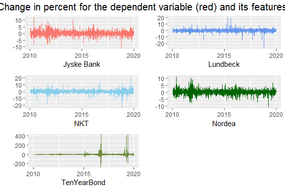

```r
Plot_Collected<-ggarrange(Plot1, Plot2, Plot3, Plot4, Plot5, ncol = 2, nrow = 3)
annotate_figure(Plot_Collected, top = text_grob("Change in percent for the dependent variable (red) and its features", size = 15))
```

```r
Plot1 <-  data_JyskeBank_Change %>% ggplot(aes(x = JyskeBank, col= "red") ) +   geom_density()  + theme(legend.position = "none")+ geom_vline(aes(xintercept=mean(JyskeBank)),
            color="darkgrey", linetype="dashed", size=1) + labs(y="" ,x = "Jyske Bank") + scale_x_continuous(limits = c(-5,5))+ scale_y_continuous(limits = c(0,0.85))

Plot2 <-  data_JyskeBank_Change%>% ggplot(aes(x = Lundbeck)) + geom_density( col = "cornflowerblue") + theme(legend.position = "none") + geom_vline(aes(xintercept=mean(Lundbeck)),
            color="darkgrey", linetype="dashed", size=1) + labs(y="", x = "Lundbeck")+ scale_x_continuous(limits = c(-5,5))+ scale_y_continuous(limits = c(0,0.85))

Plot3 <-  data_JyskeBank_Change  %>% ggplot(aes(x = NKT)) + geom_density(col= "skyblue") + theme(legend.position = "none")+ geom_vline(aes(xintercept=mean(NKT)),
            color="darkgrey", linetype="dashed", size=1)  + labs(y="", x = "NKT")+ scale_x_continuous(limits = c(-5,5))+ scale_y_continuous(limits = c(0,0.85))

Plot4 <-  data_JyskeBank_Change %>%ggplot(aes(x = Nordea)) + geom_density(col= "darkgreen") + theme(legend.position = "none")+ geom_vline(aes(xintercept=mean(Nordea)),
            color="darkgrey", linetype="dashed", size=1) + labs(y="", x = "Nordea") + scale_x_continuous(limits = c(-5,5))+ scale_y_continuous(limits = c(0,0.85))

Plot5 <-  data_JyskeBank_Change %>% ggplot(aes(x = TenYearBond)) + geom_density(col= "darkolivegreen4") + theme(legend.position = "none") + geom_vline(aes(xintercept=mean(TenYearBond)),
            color="darkgrey", linetype="dashed", size=1) + labs(y="", x = "TenYearBond")+ scale_x_continuous(limits = c(-5,5))+ scale_y_continuous(limits = c(0,0.85))
```

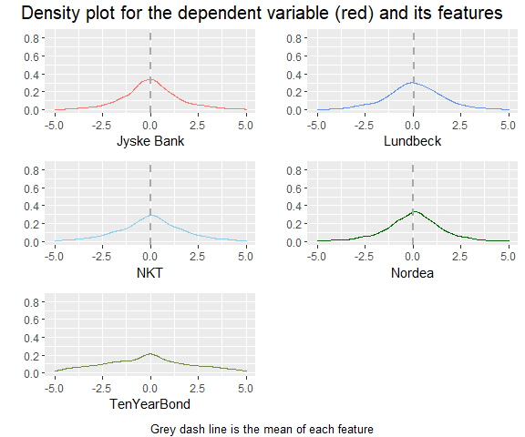

```r
Plot_Collected<-ggarrange(Plot1, Plot2, Plot3, Plot4, Plot5, ncol = 2, nrow = 3)
annotate_figure(Plot_Collected, top = text_grob("Density plot for the dependent variable (red) and its features", size = 15),  bottom = text_grob("Grey dash line is the mean of each feature", size = 10))
```

Cleaning the environment from unnecessary data sets.

```r
rm(Plot1, Plot_Baverian, Plot2, Plot3, Plot4, Plot5, Plot6, Plot_Collected, data_JyskeBank_plot, data_JyskeBank_Change)
```

## Saving the data set

The Jyske Bank data set is now done and ready for forecast. It is saved as a cvs-file and uploaded on [Github](https://github.com/andreasbj77/Master-thesis?fbclid=IwAR1-uXAsXOvRxWwDzpfhzjiqyOhil9E4wklrK03_fRMZhLQ7EYTrooHzTw0)

```r
write_as_csv(data_JyskeBank,"DataCreationJyskeBank.csv")
```

```r
rm(data_JyskeBank)
```

# Finance - Vestas

## Selection of features

Calculating granger causality for each value and *Vestas*. Five lags each chosen for this study.

```r
Order_lags <- 5
DependendVariable <- data$Vestas

GC1 <- grangertest(DependendVariable ~MaerskA,  order = Order_lags, data = data) %>%
 drop_na() %>% mutate(Company = "MaerskA") %>% rename("GrangerCausitality"="Pr(>F)" ) %>%select(Company,GrangerCausitality) %>% mutate(Correlation = cor(data$MaerskA, DependendVariable))

GC2 <- grangertest(DependendVariable ~MaerskB,  order = Order_lags, data = data) %>%
 drop_na() %>% mutate(Company = "MaerskB") %>% rename("GrangerCausitality"="Pr(>F)" ) %>%select(Company,GrangerCausitality) %>% mutate(Correlation = cor(data$MaerskB, DependendVariable))

GC3 <- grangertest(DependendVariable ~ Baverian,  order = Order_lags, data = data) %>%
 drop_na() %>% mutate(Company = "Baverian") %>% rename("GrangerCausitality"="Pr(>F)" ) %>%select(Company,GrangerCausitality)%>% mutate(Correlation = cor(DependendVariable , data$Baverian))

GC4 <- grangertest(DependendVariable ~ Carlsberg,  order = Order_lags, data = data) %>%
 drop_na() %>% mutate(Company = "Carlsberg") %>% rename("GrangerCausitality"="Pr(>F)" ) %>%select(Company,GrangerCausitality) %>% mutate(Correlation = cor(DependendVariable , data$Carlsberg))

GC5 <- grangertest(DependendVariable ~ Coloplast,  order = Order_lags, data = data) %>%
 drop_na() %>% mutate(Company = "Coloplast") %>% rename("GrangerCausitality"="Pr(>F)" ) %>%select(Company,GrangerCausitality) %>% mutate(Correlation = cor(DependendVariable , data$Coloplast))

GC6 <- grangertest(DependendVariable ~ DanskeBank,  order = Order_lags, data = data) %>%
 drop_na() %>% mutate(Company = "DanskeBank") %>% rename("GrangerCausitality"="Pr(>F)" ) %>%select(Company,GrangerCausitality) %>% mutate(Correlation = cor(DependendVariable , data$DanskeBank))

GC7 <- grangertest(DependendVariable ~ DSV,  order = Order_lags, data = data) %>%
 drop_na() %>% mutate(Company = "DSV") %>% rename("GrangerCausitality"="Pr(>F)" ) %>%select(Company,GrangerCausitality) %>% mutate(Correlation = cor(DependendVariable , data$DSV))

GC8 <- grangertest(DependendVariable ~ FLSmidth,  order = Order_lags, data = data) %>%
 drop_na() %>% mutate(Company = "FLSmidth") %>% rename("GrangerCausitality"="Pr(>F)" ) %>%select(Company,GrangerCausitality) %>% mutate(Correlation = cor(DependendVariable , data$FLSmidth))

GC9 <- grangertest(DependendVariable ~ Genmab,  order = Order_lags, data = data) %>%
 drop_na() %>% mutate(Company = "Genmab") %>% rename("GrangerCausitality"="Pr(>F)" ) %>%select(Company,GrangerCausitality) %>% mutate(Correlation = cor(DependendVariable , data$Genmab))

GC10 <- grangertest(DependendVariable ~ GN,  order = Order_lags, data = data) %>%
 drop_na() %>% mutate(Company = "GN") %>% rename("GrangerCausitality"="Pr(>F)" ) %>%select(Company,GrangerCausitality)%>% mutate(Correlation = cor(DependendVariable , data$GN))

GC11 <- grangertest(DependendVariable ~ JyskeBank,  order = Order_lags, data = data) %>%
 drop_na() %>% mutate(Company = "JyskeBank") %>% rename("GrangerCausitality"="Pr(>F)" ) %>%select(Company,GrangerCausitality)%>% mutate(Correlation = cor(DependendVariable , data$JyskeBank))

GC12 <- grangertest(DependendVariable ~ Lundbeck,  order = Order_lags, data = data) %>%
 drop_na() %>% mutate(Company = "Lundbeck") %>% rename("GrangerCausitality"="Pr(>F)" ) %>%select(Company,GrangerCausitality)%>% mutate(Correlation = cor(DependendVariable , data$Lundbeck))

GC13 <- grangertest(DependendVariable ~ NKT,  order = Order_lags, data = data) %>%
 drop_na() %>% mutate(Company = "NKT") %>% rename("GrangerCausitality"="Pr(>F)" ) %>%select(Company,GrangerCausitality)%>% mutate(Correlation = cor(DependendVariable , data$NKT))

GC14 <- grangertest(DependendVariable ~ Nordea,  order = Order_lags, data = data) %>%
 drop_na() %>% mutate(Company = "Nordea") %>% rename("GrangerCausitality"="Pr(>F)" ) %>%select(Company,GrangerCausitality)%>% mutate(Correlation = cor(DependendVariable , data$Nordea))

GC15 <- grangertest(DependendVariable ~ NovoNordisk,  order = Order_lags, data = data) %>%
 drop_na() %>% mutate(Company = "NovoNordisk") %>% rename("GrangerCausitality"="Pr(>F)" ) %>%select(Company,GrangerCausitality) %>% mutate(Correlation = cor(DependendVariable , data$NovoNordisk))

GC16 <- grangertest(DependendVariable ~ Novozymes,  order = Order_lags, data = data) %>%
 drop_na() %>% mutate(Company = "Novozymes") %>% rename("GrangerCausitality"="Pr(>F)" ) %>%select(Company,GrangerCausitality) %>% mutate(Correlation = cor(DependendVariable , data$Novozymes))

GC17 <- grangertest(DependendVariable ~ Tryg,  order = Order_lags, data = data) %>%
 drop_na() %>% mutate(Company = "Tryg") %>% rename("GrangerCausitality"="Pr(>F)" ) %>%select(Company,GrangerCausitality) %>% mutate(Correlation = cor(DependendVariable , data$Tryg))

GC18 <- grangertest(DependendVariable ~ WilliamDemant,  order = Order_lags, data = data) %>%
 drop_na() %>% mutate(Company = "WilliamDemant") %>% rename("GrangerCausitality"="Pr(>F)" ) %>%select(Company,GrangerCausitality) %>% mutate(Correlation = cor(DependendVariable , data$WilliamDemant))

GC19 <- grangertest(DependendVariable ~ OilPrice,  order = Order_lags, data = data) %>%
 drop_na() %>% mutate(Company = "OilPrice") %>% rename("GrangerCausitality"="Pr(>F)" ) %>%select(Company,GrangerCausitality) %>% mutate(Correlation = cor(DependendVariable , data$OilPrice))

GC20 <- grangertest(DependendVariable ~ USD,  order = Order_lags, data = data) %>%
 drop_na() %>% mutate(Company = "USD") %>% rename("GrangerCausitality"="Pr(>F)" ) %>%select(Company,GrangerCausitality) %>% mutate(Correlation = cor(DependendVariable , data$USD))

GC21 <- grangertest(DependendVariable ~ GBP,  order = Order_lags, data = data) %>%
 drop_na() %>% mutate(Company = "GBP") %>% rename("GrangerCausitality"="Pr(>F)" ) %>%select(Company,GrangerCausitality) %>% mutate(Correlation = cor(DependendVariable , data$GBP))

GC22 <- grangertest(DependendVariable ~ NOK,  order = Order_lags, data = data) %>%
 drop_na() %>% mutate(Company = "NOK") %>% rename("GrangerCausitality"="Pr(>F)" ) %>%select(Company,GrangerCausitality) %>% mutate(Correlation = cor(DependendVariable , data$NOK))

GC23 <- grangertest(DependendVariable ~ SEK,  order = Order_lags, data = data) %>%
 drop_na() %>% mutate(Company = "SEK") %>% rename("GrangerCausitality"="Pr(>F)" ) %>%select(Company,GrangerCausitality) %>% mutate(Correlation = cor(DependendVariable , data$SEK))

GC24 <- grangertest(DependendVariable ~ CNY,  order = Order_lags, data = data) %>%
 drop_na() %>% mutate(Company = "CNY") %>% rename("GrangerCausitality"="Pr(>F)" ) %>%select(Company,GrangerCausitality) %>% mutate(Correlation = cor(DependendVariable , data$CNY))

GC25 <- grangertest(DependendVariable ~ C20index,  order = Order_lags, data = data) %>%
 drop_na() %>% mutate(Company = "C20index") %>% rename("GrangerCausitality"="Pr(>F)" ) %>%select(Company,GrangerCausitality) %>% mutate(Correlation = cor(DependendVariable , data$C20index))

GC26 <- grangertest(DependendVariable ~ TwoYearBond,  order = Order_lags, data = data) %>%
 drop_na() %>% mutate(Company = "TwoYearBond") %>% rename("GrangerCausitality"="Pr(>F)" ) %>%select(Company,GrangerCausitality) %>% mutate(Correlation = cor(DependendVariable , data$TwoYearBond))

GC27 <- grangertest(DependendVariable ~ TenYearBond,  order = Order_lags, data = data) %>%
 drop_na() %>% mutate(Company = "TenYearBond") %>% rename("GrangerCausitality"="Pr(>F)" ) %>%select(Company,GrangerCausitality) %>% mutate(Correlation = cor(DependendVariable , data$TenYearBond))

GC28 <- grangertest(DependendVariable ~ GoldFutures,  order = Order_lags, data = data) %>%
 drop_na() %>% mutate(Company = "GoldFutures") %>% rename("GrangerCausitality"="Pr(>F)" ) %>%select(Company,GrangerCausitality) %>% mutate(Correlation = cor(DependendVariable , data$GoldFutures))

GC_Vestas <- rbind(GC1,GC2,GC3,GC4,GC5,GC6,GC7,GC8,GC9,GC10,GC11,GC12,GC13,GC14,GC15,GC16,GC17,GC18,GC19,GC20,GC21,GC22,GC23,GC24,GC25,GC26,GC27,GC28) %>% as.data.frame()
```

The significant features is chosen.

```r
GC_Vestas %>%
    filter(GrangerCausitality <= 0.05)
```

| Company | GrangerCausitality | Correlation |
| --- | --- | --- |
| MaerskA | 0.023746498 | 0.2370728 |
| Coloplast | 0.003551768 | 0.7778315 |
| Genmab | 0.003883790 | 0.9188087 |
| GN | 0.013129075 | 0.7310094 |
| Lundbeck | 0.008288608 | 0.7946600 |
| NovoNordisk | 0.004084655 | 0.6912813 |
| USD | 0.007607510 | 0.7689950 |
| NOK | 0.000796658 | -0.9191962 |
| C20index | 0.008441009 | 0.8521769 |

```r
data_Vestas <- data %>%
  select(Date, Vestas, MaerskA, Coloplast, Genmab, GN, Lundbeck, NovoNordisk, USD, NOK, C20index)
```

Cleaning the environment from unnecessary data sets.

```r
rm(GC1,GC2,GC3,GC4,GC5,GC6,GC7,GC8,GC9,GC10,GC11,GC12,GC13,GC14,GC15,GC16,GC17,GC18,GC19,GC20,GC21,GC22,GC23,GC24,GC25,GC26,GC27,GC28,GC_Vestas,DependendVariable,Order_lags)
```

## Investegating the data

Plotting each variable individually.

```r
Plot1 <-  data_Vestas  %>% ggplot(aes(y = Vestas, x = Date,  col= "red") ) + geom_line()  + theme(legend.position = "none")  + labs(y="" ,x = "Vestas")

Plot2 <-  data_Vestas  %>% ggplot(aes(y = MaerskA, x = Date)) + geom_line(col = "cornflowerblue") + theme(legend.position = "none") + labs(y= "", x = " Maersk A")

Plot3 <-  data_Vestas %>%   ggplot(aes(y =  Coloplast, x = Date)) + geom_line(col= "darkolivegreen4") + theme(legend.position = "none") + labs(y="", x = "  Coloplast")

Plot4 <-  data_Vestas %>% ggplot(aes(y =Genmab, x = Date)) + geom_line(col = "darkslategray3") + theme(legend.position = "none")     + labs(y="" ,x = "Genmab")

Plot5 <-  data_Vestas %>% ggplot(aes(y = GN, x = Date)) + geom_line(col = "darkseagreen4") + theme(legend.position = "none")  + labs(y="" ,x = "GN")

Plot6 <-  data_Vestas %>% ggplot(aes(y = Lundbeck, x = Date)) + geom_line(col = "chartreuse4") + theme(legend.position = "none")  + labs(y="" ,x = "Lundbeck")

Plot7 <-  data_Vestas %>% ggplot(aes(y = NovoNordisk, x = Date)) + geom_line(col = "deepskyblue3") + theme(legend.position = "none")  + labs(y="" ,x = "NovoNordisk")

Plot8 <-  data_Vestas %>% ggplot(aes(y = USD, x = Date)) + geom_line(col = "cadetblue3") + theme(legend.position = "none")  + labs(y="" ,x = "USD")

Plot9 <-  data_Vestas %>% ggplot(aes(y = NOK, x = Date)) + geom_line(col = "darkolivegreen3") + theme(legend.position = "none")  + labs(y="" ,x = "NOK")

Plot10 <-  data_Vestas %>% ggplot(aes(y = C20index, x = Date)) + geom_line(col = "darkolivegreen3") + theme(legend.position = "none")  + labs(y="" ,x = "C20index")
```

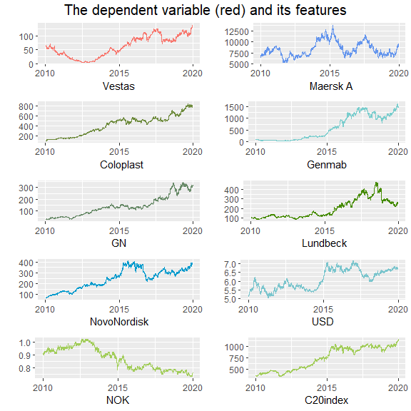

```r
Plot_Collected<-ggarrange(Plot1, Plot2, Plot3, Plot4, Plot5, Plot6, Plot7, Plot8, Plot9, Plot10, ncol = 2, nrow = 5)
annotate_figure(Plot_Collected, top = text_grob("The dependent variable (red) and its features", size = 15))
```

### Boxplot

Creating a summary in order to investigate each variable.

```r
data_Vestas %>% select(-Date) %>%  summary()
```

```
     Vestas          MaerskA        Coloplast         Genmab              GN
 Min.   :  4.81   Min.   : 5366   Min.   : 92.8   Min.   :  23.88   Min.   : 28.40
 1st Qu.: 30.69   1st Qu.: 7106   1st Qu.:211.1   1st Qu.:  71.86   1st Qu.: 72.42
 Median : 58.82   Median : 7909   Median :476.2   Median : 360.35   Median :131.10
 Mean   : 61.97   Mean   : 8343   Mean   :414.8   Mean   : 591.21   Mean   :142.28
 3rd Qu.: 91.76   3rd Qu.: 9489   3rd Qu.:530.5   3rd Qu.:1128.00   3rd Qu.:193.93
 Max.   :138.12   Max.   :13701   Max.   :844.8   Max.   :1620.00   Max.   :342.90
    Lundbeck       NovoNordisk          USD             NOK            C20index
 Min.   : 81.65   Min.   : 66.78   Min.   :5.010   Min.   :0.7300   Min.   : 335.1
 1st Qu.:113.00   1st Qu.:170.80   1st Qu.:5.590   1st Qu.:0.7900   1st Qu.: 470.3
 Median :138.55   Median :254.00   Median :6.050   Median :0.8800   Median : 765.0
 Mean   :195.23   Mean   :244.20   Mean   :6.106   Mean   :0.8703   Mean   : 738.0
 3rd Qu.:269.65   3rd Qu.:319.70   3rd Qu.:6.640   3rd Qu.:0.9500   3rd Qu.: 977.6
 Max.   :475.90   Max.   :410.70   Max.   :7.170   Max.   :1.0200   Max.   :1146.5
```

Creating a box plot for each variable. (I created two boxplot because I am not sure which one to pick).

```r
Plot1 <-  data_Vestas %>% ggplot(aes(y = Vestas, x = Date,  col= "red") ) +   geom_boxplot()  + theme(legend.position = "none") + labs(y="" ,x = "Vestas")

Plot2 <-  data_Vestas%>% ggplot(aes(y = MaerskA, x = Date)) + geom_boxplot(col = "cornflowerblue") + theme(legend.position = "none") + labs(y="", x = " MaerskA")

Plot3 <-  data_Vestas %>% ggplot(aes(y =  Coloplast, x = Date)) + geom_boxplot(col= "darkolivegreen4") + theme(legend.position = "none") + labs(y="", x = "Coloplast")

Plot4 <- data_Vestas %>% ggplot(aes(y =Genmab, x = Date)) + geom_boxplot(col = "darkslategray3") + theme(legend.position = "none")     + labs(y="" ,x = "Genmab")

Plot5 <-  data_Vestas %>% ggplot(aes(y = GN, x = Date)) + geom_boxplot(col = "darkseagreen4") + theme(legend.position = "none")  + labs(y="" ,x = "GN")

Plot6 <-  data_Vestas %>% ggplot(aes(y = Lundbeck, x = Date)) + geom_boxplot(col = "chartreuse4") + theme(legend.position = "none")  + labs(y="" ,x = "Lundbeck")

Plot7 <-  data_Vestas %>% ggplot(aes(y = NovoNordisk, x = Date)) + geom_boxplot(col = "deepskyblue3") + theme(legend.position = "none")  + labs(y="" ,x = "NovoNordisk")

Plot8 <-  data_Vestas %>% ggplot(aes(y = USD, x = Date)) + geom_boxplot(col = "cadetblue3") + theme(legend.position = "none")  + labs(y="" ,x = "USD")

Plot9 <-  data_Vestas %>% ggplot(aes(y = NOK, x = Date)) + geom_boxplot(col = "darkolivegreen3") + theme(legend.position = "none")  + labs(y="" ,x = "NOK")

Plot10 <-  data_Vestas %>% ggplot(aes(y = C20index, x = Date)) + geom_boxplot(col = "darkolivegreen3") + theme(legend.position = "none")  + labs(y="" ,x = "C20index")
```

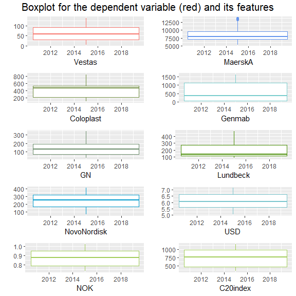

```r
Plot_Collected<-ggarrange(Plot1, Plot2, Plot3, Plot4, Plot5, Plot6, Plot7, Plot8, Plot9, Plot10, ncol = 2, nrow = 5)
annotate_figure(Plot_Collected, top = text_grob("Boxplot for the dependent variable (red) and its features", size = 15))
```

When plotting the date by using the *gather* function, the stocks is plotted in alphabetic order. To get the same order as the other plots, the plots is recorded into a number and a factor, then the number is given a level, and then given a number is given a label corresponding the name of the company.

```r
data_Vestas_plot<- gather(data_Vestas, Company, Value, -Date)
data_Vestas_plot %<>% mutate(Company = ifelse(Company == "Vestas", 1,
                           ifelse(Company == "MaerskA", 2,
                           ifelse(Company == "Coloplast", 3,
                           ifelse(Company == "Genmab", 4,
                           ifelse(Company == "GN", 5,
                           ifelse(Company == "Lundbeck", 6,
                           ifelse(Company == "NovoNordisk", 7,
                           ifelse(Company == "USD", 8,
                           ifelse(Company == "NOK", 9,
                           ifelse(Company == "C20index", 10,  "test")))))))))))
data_Vestas_plot$Company <- factor(as.numeric(data_Vestas_plot$Company),
          levels = c(1, 2, 3, 4, 5, 6, 7, 8, 9, 10),
          labels = c("Vestas", "MaerskA", "Coloplast", "Genmab", "GN", "Lundbeck", "NovoNordisk", "USD", "NOK", "C20index"))
```

The second box plot.

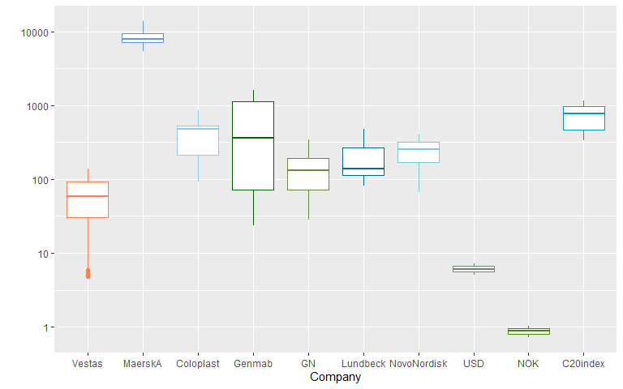

```r
data_Vestas_plot%>%
ggplot( aes(x=Company, y=Value)) + geom_boxplot(col = c("coral", "cornflowerblue", "skyblue","darkgreen", "darkolivegreen4", "deepskyblue4", "darkslategray3", "darkseagreen4", "chartreuse4", "deepskyblue3"))+ scale_y_log10()  + labs(y="", x = "Company")
```

A yearly boxplot is made for each variable. This shows if the rise/fall the stock did a year were distributed on a few observation or were more consistent.

```r
Plot1 <- data_Vestas %>% select(Date, Vestas) %>%mutate(Year = format(Date, "%Y" )) %>%  ggplot(aes(x=Year, y=Vestas)) + geom_boxplot(col = "coral")+ theme(legend.position = "none") + labs(y="" ,x = "Vestas")

Plot2 <-  data_Vestas%>% select(Date,MaerskA) %>%mutate(Year = format(Date, "%Y" ))%>% ggplot(aes(x = Year, y = MaerskA)) + geom_boxplot(col = "cornflowerblue") + theme(legend.position = "none") + labs(y="", x = " MaerskA")

Plot3 <-  data_Vestas %>%select(Date,  Coloplast) %>% mutate(Year = format(Date, "%Y" )) %>% ggplot(aes(x = Year, y =  Coloplast)) + geom_boxplot(col= "darkolivegreen4") + theme(legend.position = "none") + labs(y="", x = "Coloplast")

Plot4 <-  data_Vestas%>%select(Date, Genmab) %>% mutate(Year = format(Date, "%Y" )) %>% ggplot(aes(x = Year, y = Genmab)) + geom_boxplot(col = "darkslategray3") + theme(legend.position = "none")     + labs(y="" ,x = "Genmab")

Plot5 <-  data_Vestas %>%select(Date, GN) %>% mutate(Year = format(Date, "%Y" ))%>% ggplot(aes(y = GN, x = Year))  + geom_boxplot(col = "darkseagreen4") + theme(legend.position = "none")  + labs(y="" ,x = "GN")

Plot6 <-  data_Vestas  %>%select(Date, Lundbeck) %>% mutate(Year = format(Date, "%Y" ))  %>% ggplot(aes(y = Lundbeck, x = Year)) + geom_boxplot(col = "chartreuse4") + theme(legend.position = "none")  + labs(y="" ,x = "Lundbeck")

Plot7 <-  data_Vestas%>%select(Date, NovoNordisk) %>% mutate(Year = format(Date, "%Y" )) %>% ggplot(aes(y = NovoNordisk, x = Year))   + geom_boxplot(col = "deepskyblue3") + theme(legend.position = "none")  + labs(y="" ,x = "NovoNordisk")

Plot8 <-  data_Vestas%>%select(Date, USD) %>% mutate(Year = format(Date, "%Y" )) %>% ggplot(aes(y = USD, x = Year))   + geom_boxplot(col = "cadetblue3")  + theme(legend.position = "none")  + labs(y="" ,x = "USD")

Plot9 <-  data_Vestas%>%select(Date, NOK) %>% mutate(Year = format(Date, "%Y" )) %>% ggplot(aes(y = NOK, x = Year))   + geom_boxplot(col = "darkolivegreen3") + theme(legend.position = "none")  + labs(y="" ,x = "NOK")

Plot10 <-  data_Vestas%>%select(Date, C20index) %>% mutate(Year = format(Date, "%Y" )) %>% ggplot(aes(y = C20index, x = Year))   + geom_boxplot(col = "darkolivegreen3") + theme(legend.position = "none")  + labs(y="" ,x = "C20index")
```

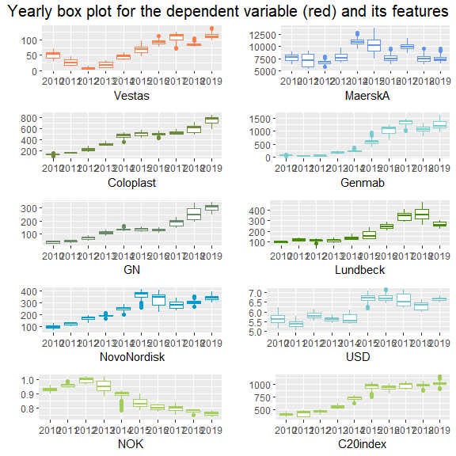

```r
Plot_Collected<-ggarrange(Plot1, Plot2, Plot3, Plot4, Plot5, Plot6, Plot7, Plot8, Plot9, Plot10, ncol = 2, nrow = 5)
annotate_figure(Plot_Collected, top = text_grob("Yearly box plot for the dependent variable (red) and its features", size = 15))
```

### Density plot

Plotting a density plot and the mean for each variable.

```r
Plot1 <-  data_Vestas %>% ggplot(aes(x = Vestas, col= "red") ) +   geom_density()  + theme(legend.position = "none")+ geom_vline(aes(xintercept=mean(Vestas)),
            color="darkgrey", linetype="dashed", size=1) + labs(y="" ,x = "Vestas")

Plot2 <-  data_Vestas%>% ggplot(aes(x = MaerskA)) + geom_density( col = "cornflowerblue") + theme(legend.position = "none") + geom_vline(aes(xintercept=mean(MaerskA)),
            color="darkgrey", linetype="dashed", size=1) + labs(y="", x = " MaerskA")

Plot3 <-  data_Vestas %>% ggplot(aes(x =  Coloplast)) + geom_density(col= "darkolivegreen4") + theme(legend.position = "none")+ geom_vline(aes(xintercept=mean(Coloplast)),
            color="darkgrey", linetype="dashed", size=1) + labs(y="", x = "Coloplast")

Plot4 <-  data_Vestas %>% ggplot(aes(x =Genmab)) + geom_density(col = "darkslategray3") + geom_vline(aes(xintercept=mean(Genmab)), color="darkgrey", linetype="dashed", size=1) + theme(legend.position = "none") + labs(y="" ,x = "Genmab")

Plot5 <-  data_Vestas %>% ggplot(aes(x = GN)) + geom_density(col = "darkseagreen4") + geom_vline(aes(xintercept=mean(GN)), color="darkgrey", linetype="dashed", size=1) + theme(legend.position = "none")  + labs(y="" ,x = "GN")

Plot6 <-  data_Vestas %>% ggplot(aes(x = Lundbeck)) + geom_density(col = "chartreuse4") + geom_vline(aes(xintercept=mean(Lundbeck)), color="darkgrey", linetype="dashed", size=1) + theme(legend.position = "none")  + labs(y="" ,x = "Lundbeck")

Plot7 <-  data_Vestas %>% ggplot(aes(x = NovoNordisk)) + geom_density(col = "deepskyblue3") + geom_vline(aes(xintercept=mean(NovoNordisk)), color="darkgrey", linetype="dashed", size=1) + theme(legend.position = "none")  + labs(y="" ,x = "NovoNordisk")

Plot8 <-  data_Vestas %>% ggplot(aes(x = USD)) + geom_density(col = "cadetblue3") + geom_vline(aes(xintercept=mean(USD)), color="darkgrey", linetype="dashed", size=1) + theme(legend.position = "none")  + labs(y="" ,x = "USD")

Plot9 <-  data_Vestas %>% ggplot(aes(x = NOK)) + geom_density(col = "darkolivegreen3")+ geom_vline(aes(xintercept=mean(NOK)), color="darkgrey", linetype="dashed", size=1) + theme(legend.position = "none")  + labs(y="" ,x = "NOK")

Plot10 <-  data_Vestas %>% ggplot(aes(x = C20index)) + geom_density(col = "darkolivegreen3")+ geom_vline(aes(xintercept=mean(C20index)), color="darkgrey", linetype="dashed", size=1) + theme(legend.position = "none")  + labs(y="" ,x = "C20index")
```

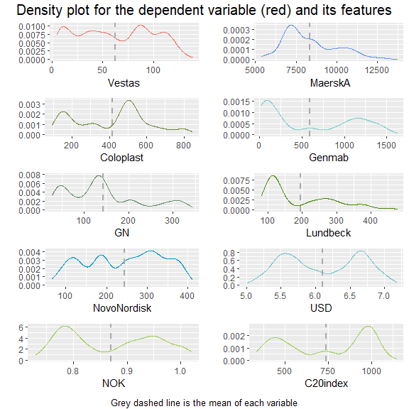

```r
Plot_Collected<-ggarrange(Plot1, Plot2, Plot3, Plot4, Plot5, Plot6, Plot7, Plot8, Plot9, Plot10, ncol = 2, nrow = 5)
annotate_figure(Plot_Collected, top = text_grob("Density plot for the dependent variable (red) and its features", size = 15),  bottom = text_grob("Grey dashed line is the mean of each variable", size = 10))
```

## The change in stock

Creating a new data set for change in price in per cent.

```r
data_Vestas_Change <- data_Vestas %>%
  mutate(Vestas  = ((Vestas-lag(Vestas))/lag(Vestas))*100,
         MaerskA = ((MaerskA-lag(MaerskA))/lag(MaerskA))*100,
         Coloplast = (( Coloplast-lag( Coloplast))/lag( Coloplast))*100,
         Genmab = ((Genmab-lag(Genmab))/lag(Genmab))*100,
         GN = ((GN-lag(GN))/lag(GN))*100,
         Lundbeck = ((Lundbeck-lag(Lundbeck))/lag(Lundbeck))*100,
         NovoNordisk = ((NovoNordisk-lag(NovoNordisk))/lag(NovoNordisk))*100,
         USD = ((USD-lag(USD))/lag(USD))*100,
         NOK = ((NOK-lag(NOK))/lag(NOK))*100,
         C20index =((C20index-lag(C20index))/lag(C20index))*100) %>%
         drop_na()
```

Plotting the change in per cent for each variable individually. This shows how volatile each variable is.

```r
Plot1 <-  data_Vestas_Change  %>% ggplot(aes(y = Vestas, x = Date,  col= "red") ) + geom_line()  + theme(legend.position = "none")  + labs(y="" ,x = "Vestas")

Plot2 <-  data_Vestas_Change  %>% ggplot(aes(y = MaerskA, x = Date)) + geom_line(col = "cornflowerblue") + theme(legend.position = "none") + labs(y= "", x = " Maersk A")

Plot3 <-  data_Vestas_Change %>%   ggplot(aes(y =  Coloplast, x = Date)) + geom_line(col= "darkolivegreen4") + theme(legend.position = "none") + labs(y="", x = "  Coloplast")

Plot4 <-  data_Vestas_Change %>% ggplot(aes(y =Genmab, x = Date)) + geom_line(col = "darkslategray3") + theme(legend.position = "none")     + labs(y="" ,x = "Genmab")

Plot5 <-  data_Vestas_Change %>% ggplot(aes(y = GN, x = Date)) + geom_line(col = "darkseagreen4") + theme(legend.position = "none")  + labs(y="" ,x = "GN")

Plot6 <-  data_Vestas_Change %>% ggplot(aes(y = Lundbeck, x = Date)) + geom_line(col = "chartreuse4") + theme(legend.position = "none")  + labs(y="" ,x = "Lundbeck")

Plot7 <-  data_Vestas_Change %>% ggplot(aes(y = NovoNordisk, x = Date)) + geom_line(col = "deepskyblue3") + theme(legend.position = "none")  + labs(y="" ,x = "NovoNordisk")

Plot8 <-  data_Vestas_Change %>% ggplot(aes(y = USD, x = Date)) + geom_line(col = "cadetblue3") + theme(legend.position = "none")  + labs(y="" ,x = "USD")

Plot9 <-  data_Vestas_Change %>% ggplot(aes(y = NOK, x = Date)) + geom_line(col = "darkolivegreen3") + theme(legend.position = "none")  + labs(y="" ,x = "NOK")

Plot10 <-  data_Vestas_Change %>% ggplot(aes(y = C20index, x = Date)) + geom_line(col = "darkolivegreen3") + theme(legend.position = "none")  + labs(y="" ,x = "C20index")
```

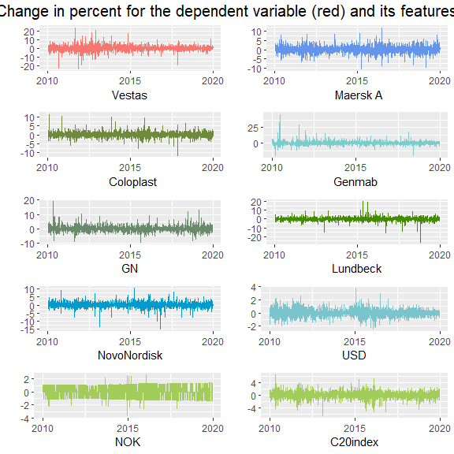

```r
Plot_Collected<-ggarrange(Plot1, Plot2, Plot3, Plot4, Plot5, Plot6, Plot7, Plot8, Plot9, Plot10, ncol = 2, nrow = 5)
annotate_figure(Plot_Collected, top = text_grob("Change in percent for the dependent variable (red) and its features", size = 15))
```

```r
Plot1 <-  data_Vestas_Change %>% ggplot(aes(x = Vestas, col= "red") ) +   geom_density()  + theme(legend.position = "none")+ geom_vline(aes(xintercept=mean(Vestas)),
            color="darkgrey", linetype="dashed", size=1) + labs(y="" ,x = "Vestas")+ scale_x_continuous(limits = c(-5,5))+ scale_y_continuous(limits = c(0,0.85))

Plot2 <-  data_Vestas_Change %>% ggplot(aes(x = MaerskA)) + geom_density( col = "cornflowerblue") + theme(legend.position = "none") + geom_vline(aes(xintercept=mean(MaerskA)),
            color="darkgrey", linetype="dashed", size=1) + labs(y="", x = " MaerskA")+ scale_x_continuous(limits = c(-5,5))+ scale_y_continuous(limits = c(0,0.85))

Plot3 <-  data_Vestas_Change %>% ggplot(aes(x =  Coloplast)) + geom_density(col= "darkolivegreen4") + theme(legend.position = "none")+ geom_vline(aes(xintercept=mean( Coloplast)),
            color="darkgrey", linetype="dashed", size=1) + labs(y="", x = "Coloplast")+ scale_x_continuous(limits = c(-5,5))+ scale_y_continuous(limits = c(0,0.85))

Plot4 <-  data_Vestas_Change %>% ggplot(aes(x =Genmab)) + geom_density(col = "darkslategray3") + geom_vline(aes(xintercept=mean(Genmab)), color="darkgrey", linetype="dashed", size=1) + theme(legend.position = "none") + labs(y="" ,x = "Genmab")+ scale_x_continuous(limits = c(-5,5))+ scale_y_continuous(limits = c(0,0.85))

Plot5 <-  data_Vestas_Change %>% ggplot(aes(x = GN)) + geom_density(col = "darkseagreen4") + geom_vline(aes(xintercept=mean(GN)), color="darkgrey", linetype="dashed", size=1) + theme(legend.position = "none")  + labs(y="" ,x = "GN")+ scale_x_continuous(limits = c(-5,5))+ scale_y_continuous(limits = c(0,0.85))

Plot6 <-  data_Vestas_Change %>% ggplot(aes(x = Lundbeck)) + geom_density(col = "chartreuse4") + geom_vline(aes(xintercept=mean(Lundbeck)), color="darkgrey", linetype="dashed", size=1) + theme(legend.position = "none")  + labs(y="" ,x = "Lundbeck")+ scale_x_continuous(limits = c(-5,5))+ scale_y_continuous(limits = c(0,0.85))

Plot7 <-  data_Vestas_Change %>% ggplot(aes(x = NovoNordisk)) + geom_density(col = "deepskyblue3") + geom_vline(aes(xintercept=mean(NovoNordisk)), color="darkgrey", linetype="dashed", size=1) + theme(legend.position = "none")  + labs(y="" ,x = "NovoNordisk")+ scale_x_continuous(limits = c(-5,5))+ scale_y_continuous(limits = c(0,0.85))

Plot8 <-  data_Vestas_Change %>% ggplot(aes(x = USD)) + geom_density(col = "cadetblue3") + geom_vline(aes(xintercept=mean(USD)), color="darkgrey", linetype="dashed", size=1) + theme(legend.position = "none")  + labs(y="" ,x = "USD")+ scale_x_continuous(limits = c(-5,5))+ scale_y_continuous(limits = c(0,0.85))

Plot9 <-  data_Vestas_Change %>% ggplot(aes(x = NOK)) + geom_density(col = "darkolivegreen3")+ geom_vline(aes(xintercept=mean(NOK)), color="darkgrey", linetype="dashed", size=1) + theme(legend.position = "none")  + labs(y="" ,x = "NOK") + scale_x_continuous(limits = c(-5,5))+ scale_y_continuous(limits = c(0,0.85))

Plot10 <-  data_Vestas_Change %>% ggplot(aes(x = C20index)) + geom_density(col = "darkolivegreen3")+ geom_vline(aes(xintercept=mean(C20index)), color="darkgrey", linetype="dashed", size=1) + theme(legend.position = "none")  + labs(y="" ,x = "C20index") + scale_x_continuous(limits = c(-5,5))+ scale_y_continuous(limits = c(0,0.85))
```

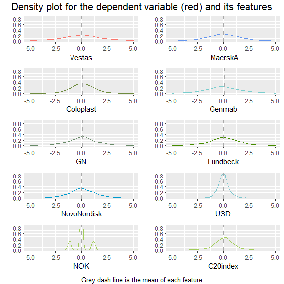

```r
Plot_Collected<-ggarrange(Plot1, Plot2, Plot3, Plot4, Plot5, Plot6, Plot7, Plot8, Plot9, Plot10, ncol = 2, nrow = 5)
annotate_figure(Plot_Collected, top = text_grob("Density plot for the dependent variable (red) and its features", size = 15),  bottom = text_grob("Grey dash line is the mean of each feature", size = 10))
```

Cleaning the environment from unnecessary data sets.

```r
rm(Plot1, Plot_Baverian, Plot2, Plot3, Plot4, Plot5, Plot6, Plot7, Plot8, Plot9, Plot10, Plot11, Plot12, Plot_Collected, data_Vestas_plot, data_Vestas_Change)
```

## Saving the data set

The Vestas data set is now done and ready for forecast. It is saved as a cvs-file and uploaded on [Github](https://github.com/andreasbj77/Master-thesis?fbclid=IwAR1-uXAsXOvRxWwDzpfhzjiqyOhil9E4wklrK03_fRMZhLQ7EYTrooHzTw0)

```r
write_as_csv(data_Vestas,"DataCreationVestas.csv")
```

```r
rm(data_Vestas)
```

# Consumption - Carlsberg

## Selection of features

Calculating granger causality for each value and *Carlsberg*. Five lags each chosen for this study.

```r
Order_lags <- 5
DependendVariable <- data$Carlsberg

GC1 <- grangertest(DependendVariable ~MaerskA,  order = Order_lags, data = data) %>%
 drop_na() %>% mutate(Company = "MaerskA") %>% rename("GrangerCausitality"="Pr(>F)" ) %>%select(Company,GrangerCausitality) %>% mutate(Correlation = cor(data$MaerskA, DependendVariable))

GC2 <- grangertest(DependendVariable ~MaerskB,  order = Order_lags, data = data) %>%
 drop_na() %>% mutate(Company = "MaerskB") %>% rename("GrangerCausitality"="Pr(>F)" ) %>%select(Company,GrangerCausitality) %>% mutate(Correlation = cor(data$MaerskB, DependendVariable))

GC3 <- grangertest(DependendVariable ~ Baverian,  order = Order_lags, data = data) %>%
 drop_na() %>% mutate(Company = "Baverian") %>% rename("GrangerCausitality"="Pr(>F)" ) %>%select(Company,GrangerCausitality)%>% mutate(Correlation = cor(DependendVariable , data$Baverian))

GC4 <- grangertest(DependendVariable ~ Coloplast,  order = Order_lags, data = data) %>%
 drop_na() %>% mutate(Company = "Coloplast") %>% rename("GrangerCausitality"="Pr(>F)" ) %>%select(Company,GrangerCausitality) %>% mutate(Correlation = cor(DependendVariable , data$Coloplast))

GC5 <- grangertest(DependendVariable ~ DanskeBank,  order = Order_lags, data = data) %>%
 drop_na() %>% mutate(Company = "DanskeBank") %>% rename("GrangerCausitality"="Pr(>F)" ) %>%select(Company,GrangerCausitality) %>% mutate(Correlation = cor(DependendVariable , data$DanskeBank))

GC6 <- grangertest(DependendVariable ~ DSV,  order = Order_lags, data = data) %>%
 drop_na() %>% mutate(Company = "DSV") %>% rename("GrangerCausitality"="Pr(>F)" ) %>%select(Company,GrangerCausitality) %>% mutate(Correlation = cor(DependendVariable , data$DSV))

GC7 <- grangertest(DependendVariable ~ FLSmidth,  order = Order_lags, data = data) %>%
 drop_na() %>% mutate(Company = "FLSmidth") %>% rename("GrangerCausitality"="Pr(>F)" ) %>%select(Company,GrangerCausitality) %>% mutate(Correlation = cor(DependendVariable , data$FLSmidth))

GC8 <- grangertest(DependendVariable ~ Genmab,  order = Order_lags, data = data) %>%
 drop_na() %>% mutate(Company = "Genmab") %>% rename("GrangerCausitality"="Pr(>F)" ) %>%select(Company,GrangerCausitality) %>% mutate(Correlation = cor(DependendVariable , data$Genmab))

GC9 <- grangertest(DependendVariable ~ GN,  order = Order_lags, data = data) %>%
 drop_na() %>% mutate(Company = "GN") %>% rename("GrangerCausitality"="Pr(>F)" ) %>%select(Company,GrangerCausitality)%>% mutate(Correlation = cor(DependendVariable , data$GN))

GC10 <- grangertest(DependendVariable ~ JyskeBank,  order = Order_lags, data = data) %>%
 drop_na() %>% mutate(Company = "JyskeBank") %>% rename("GrangerCausitality"="Pr(>F)" ) %>%select(Company,GrangerCausitality)%>% mutate(Correlation = cor(DependendVariable , data$JyskeBank))

GC11 <- grangertest(DependendVariable ~ Lundbeck,  order = Order_lags, data = data) %>%
 drop_na() %>% mutate(Company = "Lundbeck") %>% rename("GrangerCausitality"="Pr(>F)" ) %>%select(Company,GrangerCausitality)%>% mutate(Correlation = cor(DependendVariable , data$Lundbeck))

GC12 <- grangertest(DependendVariable ~ NKT,  order = Order_lags, data = data) %>%
 drop_na() %>% mutate(Company = "NKT") %>% rename("GrangerCausitality"="Pr(>F)" ) %>%select(Company,GrangerCausitality)%>% mutate(Correlation = cor(DependendVariable , data$NKT))

GC13 <- grangertest(DependendVariable ~ Nordea,  order = Order_lags, data = data) %>%
 drop_na() %>% mutate(Company = "Nordea") %>% rename("GrangerCausitality"="Pr(>F)" ) %>%select(Company,GrangerCausitality)%>% mutate(Correlation = cor(DependendVariable , data$Nordea))

GC14 <- grangertest(DependendVariable ~ NovoNordisk,  order = Order_lags, data = data) %>%
 drop_na() %>% mutate(Company = "NovoNordisk") %>% rename("GrangerCausitality"="Pr(>F)" ) %>%select(Company,GrangerCausitality) %>% mutate(Correlation = cor(DependendVariable , data$NovoNordisk))

GC15 <- grangertest(DependendVariable ~ Novozymes,  order = Order_lags, data = data) %>%
 drop_na() %>% mutate(Company = "Novozymes") %>% rename("GrangerCausitality"="Pr(>F)" ) %>%select(Company,GrangerCausitality) %>% mutate(Correlation = cor(DependendVariable , data$Novozymes))

GC16 <- grangertest(DependendVariable ~ Tryg,  order = Order_lags, data = data) %>%
 drop_na() %>% mutate(Company = "Tryg") %>% rename("GrangerCausitality"="Pr(>F)" ) %>%select(Company,GrangerCausitality) %>% mutate(Correlation = cor(DependendVariable , data$Tryg))

GC17 <- grangertest(DependendVariable ~ Vestas,  order = Order_lags, data = data) %>%
 drop_na() %>% mutate(Company = "Vestas") %>% rename("GrangerCausitality"="Pr(>F)" ) %>%select(Company,GrangerCausitality) %>% mutate(Correlation = cor(DependendVariable , data$Vestas))

GC18 <- grangertest(DependendVariable ~ WilliamDemant,  order = Order_lags, data = data) %>%
 drop_na() %>% mutate(Company = "WilliamDemant") %>% rename("GrangerCausitality"="Pr(>F)" ) %>%select(Company,GrangerCausitality) %>% mutate(Correlation = cor(DependendVariable , data$WilliamDemant))

GC19 <- grangertest(DependendVariable ~ OilPrice,  order = Order_lags, data = data) %>%
 drop_na() %>% mutate(Company = "OilPrice") %>% rename("GrangerCausitality"="Pr(>F)" ) %>%select(Company,GrangerCausitality) %>% mutate(Correlation = cor(DependendVariable , data$OilPrice))

GC20 <- grangertest(DependendVariable ~ USD,  order = Order_lags, data = data) %>%
 drop_na() %>% mutate(Company = "USD") %>% rename("GrangerCausitality"="Pr(>F)" ) %>%select(Company,GrangerCausitality) %>% mutate(Correlation = cor(DependendVariable , data$USD))

GC21 <- grangertest(DependendVariable ~ GBP,  order = Order_lags, data = data) %>%
 drop_na() %>% mutate(Company = "GBP") %>% rename("GrangerCausitality"="Pr(>F)" ) %>%select(Company,GrangerCausitality) %>% mutate(Correlation = cor(DependendVariable , data$GBP))

GC22 <- grangertest(DependendVariable ~ NOK,  order = Order_lags, data = data) %>%
 drop_na() %>% mutate(Company = "NOK") %>% rename("GrangerCausitality"="Pr(>F)" ) %>%select(Company,GrangerCausitality) %>% mutate(Correlation = cor(DependendVariable , data$NOK))

GC23 <- grangertest(DependendVariable ~ SEK,  order = Order_lags, data = data) %>%
 drop_na() %>% mutate(Company = "SEK") %>% rename("GrangerCausitality"="Pr(>F)" ) %>%select(Company,GrangerCausitality) %>% mutate(Correlation = cor(DependendVariable , data$SEK))

GC24 <- grangertest(DependendVariable ~ CNY,  order = Order_lags, data = data) %>%
 drop_na() %>% mutate(Company = "CNY") %>% rename("GrangerCausitality"="Pr(>F)" ) %>%select(Company,GrangerCausitality) %>% mutate(Correlation = cor(DependendVariable , data$CNY))

GC25 <- grangertest(DependendVariable ~ C20index,  order = Order_lags, data = data) %>%
 drop_na() %>% mutate(Company = "C20index") %>% rename("GrangerCausitality"="Pr(>F)" ) %>%select(Company,GrangerCausitality) %>% mutate(Correlation = cor(DependendVariable , data$C20index))

GC26 <- grangertest(DependendVariable ~ TwoYearBond,  order = Order_lags, data = data) %>%
 drop_na() %>% mutate(Company = "TwoYearBond") %>% rename("GrangerCausitality"="Pr(>F)" ) %>%select(Company,GrangerCausitality) %>% mutate(Correlation = cor(DependendVariable , data$TwoYearBond))

GC27 <- grangertest(DependendVariable ~ TenYearBond,  order = Order_lags, data = data) %>%
 drop_na() %>% mutate(Company = "TenYearBond") %>% rename("GrangerCausitality"="Pr(>F)" ) %>%select(Company,GrangerCausitality) %>% mutate(Correlation = cor(DependendVariable , data$TenYearBond))

GC28 <- grangertest(DependendVariable ~ GoldFutures,  order = Order_lags, data = data) %>%
 drop_na() %>% mutate(Company = "GoldFutures") %>% rename("GrangerCausitality"="Pr(>F)" ) %>%select(Company,GrangerCausitality) %>% mutate(Correlation = cor(DependendVariable , data$GoldFutures))

GC_Carlsberg <- rbind(GC1,GC2,GC3,GC4,GC5,GC6,GC7,GC8,GC9,GC10,GC11,GC12,GC13,GC14,GC15,GC16,GC17,GC18,GC19,GC20,GC21,GC22,GC23,GC24,GC25,GC26,GC27,GC28) %>% as.data.frame()
```

The significant features is chosen.

```r
GC_Carlsberg %>%
    filter(GrangerCausitality <= 0.05)
```

| Company | GrangerCausitality | Correlation |
| --- | --- | --- |
| DSV | 0.0001455822 | 0.9223453 |
| GN | 0.0287552327 | 0.8879149 |
| JyskeBank | 0.0349108628 | 0.3538789 |
| Tryg | 0.0353767484 | 0.8337953 |
| OilPrice | 0.0373286862 | -0.3842287 |

```r
data_Carlsberg <- data %>%
  select(Date, Carlsberg, DSV, GN, JyskeBank, Tryg, OilPrice)
```

Cleaning the environment from unnecessary data sets.

```r
rm(GC1,GC2,GC3,GC4,GC5,GC6,GC7,GC8,GC9,GC10,GC11,GC12,GC13,GC14,GC15,GC16,GC17,GC18,GC19,GC20,GC21,GC22,GC23,GC24,GC25,GC26,GC27,GC28,GC_Carlsberg,DependendVariable,Order_lags)
```